# Task 1: Data Loading, Cleaning & Exploratory Data Analysis

## 1.1 Load and inspect the dataset

```python
import pandas as pd
import numpy as np

df = pd.read_csv("adult.csv")

print("Dataset Shape:", df.shape)

print("\nData Types:\n")
print(df.dtypes)

print("\nFirst 5 Rows:\n")
display(df.head())

print("\nDataset Info:\n")
df.info()

# Remove Extra Spaces from Object Columns
for col in df.select_dtypes(include="object"):
    df[col] = df[col].str.strip()

print("\nWhitespace Removed Successfully.")
```

```
Dataset Shape: (48842, 15)

Data Types:

age                 int64
workclass          object
fnlwgt              int64
education          object
educational-num     int64
marital-status     object
occupation         object
relationship       object
race               object
gender             object
capital-gain        int64
capital-loss        int64
hours-per-week      int64
native-country     object
income             object
dtype: object

First 5 Rows:
```

|  | age | workclass | fnlwgt | education | educational-num | marital-status | occupation | relationship | race | gender | capital-gain | capital-loss | hours-per-week | native-country | income |
| --- | --- | --- | --- | --- | --- | --- | --- | --- | --- | --- | --- | --- | --- | --- | --- |
| 0 | 25 | Private | 226802 | 11th | 7 | Never-married | Machine-op-inspct | Own-child | Black | Male | 0 | 0 | 40 | United-States | <=50K |
| 1 | 38 | Private | 89814 | HS-grad | 9 | Married-civ-spouse | Farming-fishing | Husband | White | Male | 0 | 0 | 50 | United-States | <=50K |
| 2 | 28 | Local-gov | 336951 | Assoc-acdm | 12 | Married-civ-spouse | Protective-serv | Husband | White | Male | 0 | 0 | 40 | United-States | >50K |
| 3 | 44 | Private | 160323 | Some-college | 10 | Married-civ-spouse | Machine-op-inspct | Husband | Black | Male | 7688 | 0 | 40 | United-States | >50K |
| 4 | 18 | ? | 103497 | Some-college | 10 | Never-married | ? | Own-child | White | Female | 0 | 0 | 30 | United-States | <=50K |

```
Dataset Info:

<class 'pandas.core.frame.DataFrame'>
RangeIndex: 48842 entries, 0 to 48841
Data columns (total 15 columns):
 #   Column           Non-Null Count  Dtype
---  ------           --------------  -----
 0   age              48842 non-null  int64
 1   workclass        48842 non-null  object
 2   fnlwgt           48842 non-null  int64
 3   education        48842 non-null  object
 4   educational-num  48842 non-null  int64
 5   marital-status   48842 non-null  object
 6   occupation       48842 non-null  object
 7   relationship     48842 non-null  object
 8   race             48842 non-null  object
 9   gender           48842 non-null  object
 10  capital-gain     48842 non-null  int64
 11  capital-loss     48842 non-null  int64
 12  hours-per-week   48842 non-null  int64
 13  native-country   48842 non-null  object
 14  income           48842 non-null  object
dtypes: int64(6), object(9)
memory usage: 5.6+ MB

Whitespace Removed Successfully.
```

- The dataset was loaded successfully.
- It contains approximately **48,842 rows and 15 columns**.
- The dataset includes both **numerical** and **categorical** features.

## 1.2 Handle missing values

```python
df.replace("?", np.nan, inplace=True)

print("Missing Values in Each Column:\n")
print(df.isnull().sum())

df.dropna(inplace=True)

print("\nDataset Shape After Removing Missing Values:", df.shape)
```

```
Missing Values in Each Column:

age                   0
workclass          2799
fnlwgt                0
education             0
educational-num       0
marital-status        0
occupation         2809
relationship          0
race                  0
gender                0
capital-gain          0
capital-loss          0
hours-per-week        0
native-country      857
income                0
dtype: int64

Dataset Shape After Removing Missing Values: (45222, 15)
```

## 1.3 Drop Redundant Columns

```python
df.drop(columns=["fnlwgt", "education"], inplace=True)

print("Dataset Shape:", df.shape)

print(df.columns)
```

```
Dataset Shape: (45222, 13)
Index(['age', 'workclass', 'educational-num', 'marital-status', 'occupation',
       'relationship', 'race', 'gender', 'capital-gain', 'capital-loss',
       'hours-per-week', 'native-country', 'income'],
      dtype='object')
```

- The **fnlwgt** column was removed because it is a census sampling weight and does not help predict income.
- The **education** column was removed because the **educational-num** column already contains the same information in numerical form.

## 1.4 Encode the Target

```python
df["income"] = (df["income"] == ">50K").astype(int)

print(df["income"].value_counts())
```

```
income
0    34014
1    11208
Name: count, dtype: int64
```

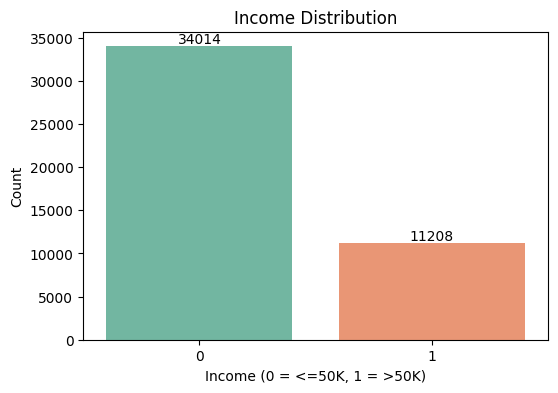

```python
import matplotlib.pyplot as plt
import seaborn as sns

plt.figure(figsize=(6,4))

ax = sns.countplot(x="income", data=df, palette="Set2")

for container in ax.containers:
    ax.bar_label(container)

plt.title("Income Distribution")
plt.xlabel("Income (0 = <=50K, 1 = >50K)")
plt.ylabel("Count")
plt.show()
```

- The target variable was converted into binary format.
- **0** represents income less than or equal to **50K**.
- **1** represents income greater than **50K**.

## 1.5 Exploratory Visualisations

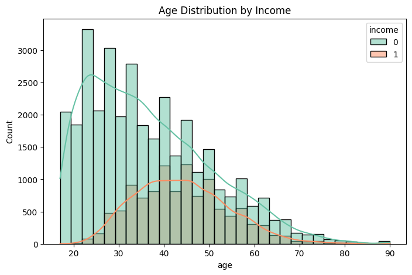

```python
# age distribution
plt.figure(figsize=(8,5))

sns.histplot(data=df, x="age", hue="income", bins=30, kde=True, palette="Set2")
plt.title("Age Distribution by Income")
plt.show()
```

- People with higher income are generally concentrated in the middle-age group, while younger individuals mostly belong to the lower-income category.

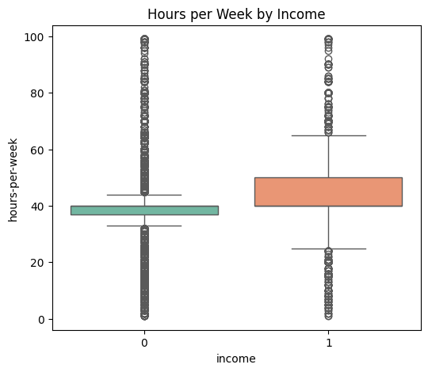

```python
# hours-per-week Boxplot
plt.figure(figsize=(6,5))

sns.boxplot(x="income", y="hours-per-week", data=df, palette="Set2")
plt.title("Hours per Week by Income")
plt.show()
```

- Individuals earning more than 50K generally work more hours per week than those earning 50K or less.

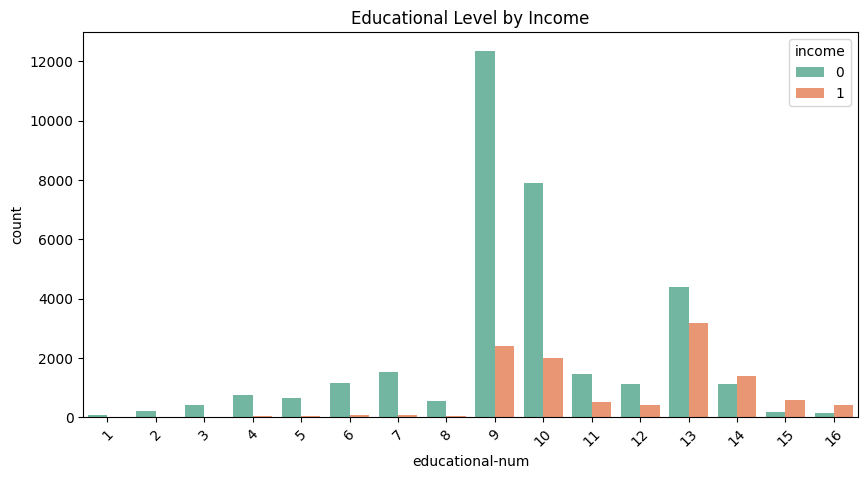

```python
# Educational Level Countplot
plt.figure(figsize=(10,5))

sns.countplot(x="educational-num", hue="income", data=df, palette="Set2")
plt.title("Educational Level by Income")
plt.xticks(rotation=45)
plt.show()
```

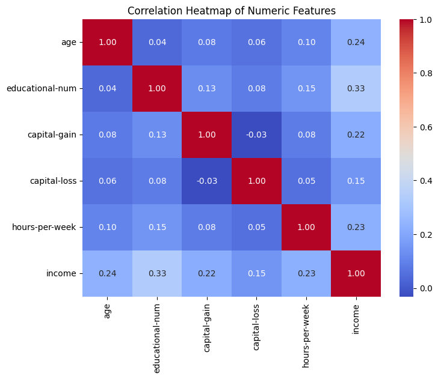

```python
# Correlation heatmap of numeric columns (including encoded target)
plt.figure(figsize=(8,6))

numeric_cols = ["age", "educational-num", "capital-gain", "capital-loss", "hours-per-week", "income"]
corr = df[numeric_cols].corr()

sns.heatmap(corr, annot=True, cmap="coolwarm", fmt=".2f")
plt.title("Correlation Heatmap of Numeric Features")
plt.show()
```

- The heatmap shows the relationship between numerical features. Features with higher positive correlation to the target variable are more useful for predicting income.

## 1.6 Encode Categoricals & Scale Numerics

```python
from sklearn.model_selection import train_test_split
from sklearn.preprocessing import StandardScaler

X = df.drop("income", axis=1)
y = df["income"]

# One-Hot Encode Categorical Columns
X = pd.get_dummies(X, drop_first=True)

print("Shape after One-Hot Encoding:", X.shape)

num_cols = [
    "age",
    "educational-num",
    "capital-gain",
    "capital-loss",
    "hours-per-week"
]

scaler = StandardScaler()
X[num_cols] = scaler.fit_transform(X[num_cols])

X_train, X_test, y_train, y_test = train_test_split(
    X,
    y,
    test_size=0.20,
    random_state=42,
    stratify=y
)

print("\nTraining Features :", X_train.shape)
print("Testing Features  :", X_test.shape)
print("Training Labels   :", y_train.shape)
print("Testing Labels    :", y_test.shape)

print("\nTraining Class Distribution")
print(y_train.value_counts(normalize=True))

print("\nTesting Class Distribution")
print(y_test.value_counts(normalize=True))
```

```
Shape after One-Hot Encoding: (45222, 80)

Training Features : (36177, 80)
Testing Features  : (9045, 80)
Training Labels   : (36177,)
Testing Labels    : (9045,)

Training Class Distribution
income
0    0.752163
1    0.247837
Name: proportion, dtype: float64

Testing Class Distribution
income
0    0.752128
1    0.247872
Name: proportion, dtype: float64
```

- The categorical variables were converted into numerical format using **One-Hot Encoding**.
- Numerical features were standardized using **StandardScaler**, while one-hot encoded binary columns were left unchanged.
- The dataset was split into **80% training** and **20% testing** sets.

# Task 2: MLP Architecture — Baseline ANN

## 2.1 Define the Reusable `build_ann()` Function

```python
import tensorflow as tf
from tensorflow.keras.models import Sequential
from tensorflow.keras.layers import Dense, BatchNormalization

def build_ann(
    input_dim,
    hidden_units=[128, 64],
    activation="relu",
    initializer="glorot_uniform",
    use_batch_norm=False,
    optimizer="adam",
    loss="binary_crossentropy"
):
    model = Sequential()

    # First Hidden Layer
    model.add(Dense(hidden_units[0],
                    activation=activation,
                    kernel_initializer=initializer,
                    input_dim=input_dim))

    if use_batch_norm:
        model.add(BatchNormalization())

    # Second Hidden Layer
    model.add(Dense(hidden_units[1],
                    activation=activation,
                    kernel_initializer=initializer))

    if use_batch_norm:
        model.add(BatchNormalization())

    # Output Layer
    model.add(Dense(1, activation="sigmoid"))

    # Compile Model
    model.compile(
        optimizer=optimizer,
        loss=loss,
        metrics=["accuracy"]
    )

    return model
```

- A reusable `build_ann()` function was created to build different ANN models easily.
- The function allows changing parameters such as hidden units, activation function, optimizer, initializer, and batch normalization.
- Using a single function ensures all future experiments are consistent and only one parameter changes at a time.

## 2.2 Baseline ANN Architecture

```python
model = build_ann(input_dim=X_train.shape[1])

model.summary()
```

```
Model: "sequential"
```

```
┏━━━━━━━━━━━━━━━━━━━━━━━━━━━━━━━━━┳━━━━━━━━━━━━━━━━━━━━━━━━┳━━━━━━━━━━━━━━━┓
┃ Layer (type)                    ┃ Output Shape           ┃       Param # ┃
┡━━━━━━━━━━━━━━━━━━━━━━━━━━━━━━━━━╇━━━━━━━━━━━━━━━━━━━━━━━━╇━━━━━━━━━━━━━━━┩
│ dense (Dense)                   │ (None, 128)            │        10,368 │
├─────────────────────────────────┼────────────────────────┼───────────────┤
│ dense_1 (Dense)                 │ (None, 64)             │         8,256 │
├─────────────────────────────────┼────────────────────────┼───────────────┤
│ dense_2 (Dense)                 │ (None, 1)              │            65 │
└─────────────────────────────────┴────────────────────────┴───────────────┘
```

```
 Total params: 18,689 (73.00 KB)
```

```
 Trainable params: 18,689 (73.00 KB)
```

```
 Non-trainable params: 0 (0.00 B)
```

- The baseline ANN consists of two hidden layers with **128** and **64** neurons using the **ReLU** activation function.
- The output layer contains **one neuron** with a **Sigmoid** activation function because this is a binary classification problem.
- Sigmoid produces an output between **0 and 1**, representing the probability of belonging to the positive class (>50K income).

### Why Sigmoid is Used?

- Sigmoid is used because the problem has only **two classes** (<=50K and >50K).
- It returns a probability value between **0 and 1**.
- A single output neuron with Sigmoid is more efficient than using two output neurons with Softmax for binary classification.

```python
from tensorflow import keras
from tensorflow.keras import layers

# Build Baseline ANN
model_base = keras.Sequential([

    layers.Dense(
        128,
        activation="relu",
        kernel_initializer="glorot_uniform",
        input_shape=(X_train.shape[1],)
    ),

    layers.Dense(
        64,
        activation="relu",
        kernel_initializer="glorot_uniform"
    ),

    layers.Dense(
        1,
        activation="sigmoid"
    )

])

# Compile Model
model_base.compile(
    optimizer="adam",
    loss="binary_crossentropy",
    metrics=["accuracy"]
)

# Display Model Summary
model_base.summary()
```

```
Model: "sequential_1"
```

```
┏━━━━━━━━━━━━━━━━━━━━━━━━━━━━━━━━━┳━━━━━━━━━━━━━━━━━━━━━━━━┳━━━━━━━━━━━━━━━┓
┃ Layer (type)                    ┃ Output Shape           ┃       Param # ┃
┡━━━━━━━━━━━━━━━━━━━━━━━━━━━━━━━━━╇━━━━━━━━━━━━━━━━━━━━━━━━╇━━━━━━━━━━━━━━━┩
│ dense_3 (Dense)                 │ (None, 128)            │        10,368 │
├─────────────────────────────────┼────────────────────────┼───────────────┤
│ dense_4 (Dense)                 │ (None, 64)             │         8,256 │
├─────────────────────────────────┼────────────────────────┼───────────────┤
│ dense_5 (Dense)                 │ (None, 1)              │            65 │
└─────────────────────────────────┴────────────────────────┴───────────────┘
```

```
 Total params: 18,689 (73.00 KB)
```

```
 Trainable params: 18,689 (73.00 KB)
```

```
 Non-trainable params: 0 (0.00 B)
```

```python
input_dim = X_train.shape[1]

layer1 = (input_dim * 128) + 128
layer2 = (128 * 64) + 64
output = (64 * 1) + 1

total_params = layer1 + layer2 + output

print(f"Input Features : {input_dim}")
print(f"Layer 1 Parameters : {layer1}")
print(f"Layer 2 Parameters : {layer2}")
print(f"Output Layer Parameters : {output}")
print(f"Total Trainable Parameters : {total_params}")
```

```
Input Features : 80
Layer 1 Parameters : 10368
Layer 2 Parameters : 8256
Output Layer Parameters : 65
Total Trainable Parameters : 18689
```

### Why Sigmoid is Used Instead of Softmax?

The Adult Income dataset is a **binary classification** problem with two classes: **<=50K** and **>50K**.

- **Sigmoid** produces a single probability between **0 and 1**, representing the probability that a sample belongs to the positive class (>50K).
- If the probability is greater than **0.5**, the sample is classified as class **1**; otherwise, it is classified as class **0**.
- A single Sigmoid output neuron is more efficient than using a two-neuron Softmax layer for binary classification because it requires fewer parameters while providing the same decision capability.

Therefore, **Sigmoid** is the preferred activation function for the output layer in binary classification tasks.

## 2.3 Train the Baseline Model

```python
model_base = build_ann(input_dim=X_train.shape[1])

history_base = model_base.fit(
    X_train,
    y_train,
    epochs=50,
    batch_size=64,
    validation_split=0.1,
    verbose=1
)
```

```
509/509 ━━━━━━━━━━━━━━━━━━━━ 4s 5ms/step - accuracy: 0.8428 - loss: 0.3353 - val_accuracy: 0.8524 - val_loss: 0.3231
509/509 ━━━━━━━━━━━━━━━━━━━━ 2s 3ms/step - accuracy: 0.8529 - loss: 0.3141 - val_accuracy: 0.8513 - val_loss: 0.3207
509/509 ━━━━━━━━━━━━━━━━━━━━ 2s 4ms/step - accuracy: 0.8553 - loss: 0.3101 - val_accuracy: 0.8516 - val_loss: 0.3208
509/509 ━━━━━━━━━━━━━━━━━━━━ 2s 3ms/step - accuracy: 0.8567 - loss: 0.3074 - val_accuracy: 0.8532 - val_loss: 0.3193
509/509 ━━━━━━━━━━━━━━━━━━━━ 1s 3ms/step - accuracy: 0.8584 - loss: 0.3037 - val_accuracy: 0.8516 - val_loss: 0.3210
509/509 ━━━━━━━━━━━━━━━━━━━━ 1s 3ms/step - accuracy: 0.8598 - loss: 0.3009 - val_accuracy: 0.8458 - val_loss: 0.3267
509/509 ━━━━━━━━━━━━━━━━━━━━ 1s 3ms/step - accuracy: 0.8601 - loss: 0.2984 - val_accuracy: 0.8560 - val_loss: 0.3192
509/509 ━━━━━━━━━━━━━━━━━━━━ 2s 4ms/step - accuracy: 0.8618 - loss: 0.2957 - val_accuracy: 0.8579 - val_loss: 0.3197
509/509 ━━━━━━━━━━━━━━━━━━━━ 2s 4ms/step - accuracy: 0.8634 - loss: 0.2925 - val_accuracy: 0.8477 - val_loss: 0.3229
509/509 ━━━━━━━━━━━━━━━━━━━━ 1s 3ms/step - accuracy: 0.8654 - loss: 0.2904 - val_accuracy: 0.8541 - val_loss: 0.3197
509/509 ━━━━━━━━━━━━━━━━━━━━ 1s 3ms/step - accuracy: 0.8658 - loss: 0.2887 - val_accuracy: 0.8530 - val_loss: 0.3174
509/509 ━━━━━━━━━━━━━━━━━━━━ 1s 3ms/step - accuracy: 0.8668 - loss: 0.2859 - val_accuracy: 0.8582 - val_loss: 0.3181
509/509 ━━━━━━━━━━━━━━━━━━━━ 1s 3ms/step - accuracy: 0.8688 - loss: 0.2837 - val_accuracy: 0.8519 - val_loss: 0.3166
509/509 ━━━━━━━━━━━━━━━━━━━━ 1s 3ms/step - accuracy: 0.8691 - loss: 0.2814 - val_accuracy: 0.8535 - val_loss: 0.3202
509/509 ━━━━━━━━━━━━━━━━━━━━ 1s 3ms/step - accuracy: 0.8692 - loss: 0.2797 - val_accuracy: 0.8546 - val_loss: 0.3196
509/509 ━━━━━━━━━━━━━━━━━━━━ 2s 3ms/step - accuracy: 0.8707 - loss: 0.2780 - val_accuracy: 0.8510 - val_loss: 0.3193
509/509 ━━━━━━━━━━━━━━━━━━━━ 3s 4ms/step - accuracy: 0.8716 - loss: 0.2755 - val_accuracy: 0.8538 - val_loss: 0.3244
509/509 ━━━━━━━━━━━━━━━━━━━━ 2s 3ms/step - accuracy: 0.8726 - loss: 0.2740 - val_accuracy: 0.8579 - val_loss: 0.3228
509/509 ━━━━━━━━━━━━━━━━━━━━ 2s 3ms/step - accuracy: 0.8726 - loss: 0.2723 - val_accuracy: 0.8496 - val_loss: 0.3273
509/509 ━━━━━━━━━━━━━━━━━━━━ 1s 3ms/step - accuracy: 0.8744 - loss: 0.2696 - val_accuracy: 0.8532 - val_loss: 0.3233
509/509 ━━━━━━━━━━━━━━━━━━━━ 1s 3ms/step - accuracy: 0.8764 - loss: 0.2674 - val_accuracy: 0.8488 - val_loss: 0.3297
509/509 ━━━━━━━━━━━━━━━━━━━━ 1s 3ms/step - accuracy: 0.8759 - loss: 0.2663 - val_accuracy: 0.8549 - val_loss: 0.3292
509/509 ━━━━━━━━━━━━━━━━━━━━ 2s 4ms/step - accuracy: 0.8752 - loss: 0.2650 - val_accuracy: 0.8516 - val_loss: 0.3303
509/509 ━━━━━━━━━━━━━━━━━━━━ 2s 4ms/step - accuracy: 0.8790 - loss: 0.2629 - val_accuracy: 0.8472 - val_loss: 0.3437
509/509 ━━━━━━━━━━━━━━━━━━━━ 1s 3ms/step - accuracy: 0.8782 - loss: 0.2613 - val_accuracy: 0.8510 - val_loss: 0.3378
509/509 ━━━━━━━━━━━━━━━━━━━━ 1s 3ms/step - accuracy: 0.8797 - loss: 0.2596 - val_accuracy: 0.8546 - val_loss: 0.3421
509/509 ━━━━━━━━━━━━━━━━━━━━ 1s 3ms/step - accuracy: 0.8797 - loss: 0.2585 - val_accuracy: 0.8532 - val_loss: 0.3342
509/509 ━━━━━━━━━━━━━━━━━━━━ 1s 3ms/step - accuracy: 0.8795 - loss: 0.2567 - val_accuracy: 0.8494 - val_loss: 0.3420
509/509 ━━━━━━━━━━━━━━━━━━━━ 1s 3ms/step - accuracy: 0.8809 - loss: 0.2553 - val_accuracy: 0.8521 - val_loss: 0.3427
509/509 ━━━━━━━━━━━━━━━━━━━━ 1s 3ms/step - accuracy: 0.8828 - loss: 0.2533 - val_accuracy: 0.8430 - val_loss: 0.3506
509/509 ━━━━━━━━━━━━━━━━━━━━ 2s 4ms/step - accuracy: 0.8821 - loss: 0.2523 - val_accuracy: 0.8460 - val_loss: 0.3495
509/509 ━━━━━━━━━━━━━━━━━━━━ 2s 4ms/step - accuracy: 0.8838 - loss: 0.2497 - val_accuracy: 0.8449 - val_loss: 0.3490
509/509 ━━━━━━━━━━━━━━━━━━━━ 1s 3ms/step - accuracy: 0.8841 - loss: 0.2487 - val_accuracy: 0.8460 - val_loss: 0.3595
509/509 ━━━━━━━━━━━━━━━━━━━━ 1s 3ms/step - accuracy: 0.8854 - loss: 0.2471 - val_accuracy: 0.8510 - val_loss: 0.3538
509/509 ━━━━━━━━━━━━━━━━━━━━ 2s 3ms/step - accuracy: 0.8849 - loss: 0.2463 - val_accuracy: 0.8438 - val_loss: 0.3611
509/509 ━━━━━━━━━━━━━━━━━━━━ 1s 3ms/step - accuracy: 0.8849 - loss: 0.2455 - val_accuracy: 0.8510 - val_loss: 0.3620
509/509 ━━━━━━━━━━━━━━━━━━━━ 2s 3ms/step - accuracy: 0.8868 - loss: 0.2447 - val_accuracy: 0.8455 - val_loss: 0.3626
509/509 ━━━━━━━━━━━━━━━━━━━━ 3s 3ms/step - accuracy: 0.8865 - loss: 0.2427 - val_accuracy: 0.8447 - val_loss: 0.3648
509/509 ━━━━━━━━━━━━━━━━━━━━ 2s 5ms/step - accuracy: 0.8874 - loss: 0.2409 - val_accuracy: 0.8438 - val_loss: 0.3664
509/509 ━━━━━━━━━━━━━━━━━━━━ 2s 4ms/step - accuracy: 0.8877 - loss: 0.2404 - val_accuracy: 0.8405 - val_loss: 0.3725
509/509 ━━━━━━━━━━━━━━━━━━━━ 1s 3ms/step - accuracy: 0.8887 - loss: 0.2389 - val_accuracy: 0.8480 - val_loss: 0.3735
509/509 ━━━━━━━━━━━━━━━━━━━━ 1s 3ms/step - accuracy: 0.8876 - loss: 0.2378 - val_accuracy: 0.8444 - val_loss: 0.3827
509/509 ━━━━━━━━━━━━━━━━━━━━ 2s 3ms/step - accuracy: 0.8900 - loss: 0.2365 - val_accuracy: 0.8427 - val_loss: 0.3794
509/509 ━━━━━━━━━━━━━━━━━━━━ 1s 3ms/step - accuracy: 0.8893 - loss: 0.2349 - val_accuracy: 0.8483 - val_loss: 0.3766
509/509 ━━━━━━━━━━━━━━━━━━━━ 1s 3ms/step - accuracy: 0.8898 - loss: 0.2351 - val_accuracy: 0.8389 - val_loss: 0.3787
509/509 ━━━━━━━━━━━━━━━━━━━━ 1s 3ms/step - accuracy: 0.8902 - loss: 0.2343 - val_accuracy: 0.8460 - val_loss: 0.3915
509/509 ━━━━━━━━━━━━━━━━━━━━ 2s 4ms/step - accuracy: 0.8899 - loss: 0.2330 - val_accuracy: 0.8422 - val_loss: 0.3818
509/509 ━━━━━━━━━━━━━━━━━━━━ 4s 7ms/step - accuracy: 0.8909 - loss: 0.2319 - val_accuracy: 0.8452 - val_loss: 0.3943
509/509 ━━━━━━━━━━━━━━━━━━━━ 3s 3ms/step - accuracy: 0.8913 - loss: 0.2306 - val_accuracy: 0.8436 - val_loss: 0.3935
509/509 ━━━━━━━━━━━━━━━━━━━━ 1s 3ms/step - accuracy: 0.8923 - loss: 0.2296 - val_accuracy: 0.8408 - val_loss: 0.3987
```

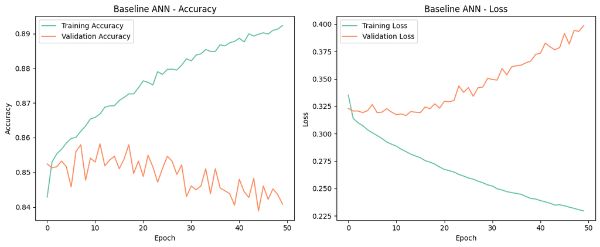

```python
plt.figure(figsize=(12,5))

# Accuracy Plot
plt.subplot(1,2,1)
plt.plot(history_base.history["accuracy"], label="Training Accuracy", color="#66C2A5")
plt.plot(history_base.history["val_accuracy"], label="Validation Accuracy", color="#FC8D62")
plt.title("Baseline ANN - Accuracy")
plt.xlabel("Epoch")
plt.ylabel("Accuracy")
plt.legend()

# Loss Plot
plt.subplot(1,2,2)
plt.plot(history_base.history["loss"], label="Training Loss", color="#66C2A5")
plt.plot(history_base.history["val_loss"], label="Validation Loss", color="#FC8D62")
plt.title("Baseline ANN - Loss")
plt.xlabel("Epoch")
plt.ylabel("Loss")
plt.legend()

plt.tight_layout()
plt.show()
```

- The baseline ANN model was trained for **50 epochs** with a **batch size of 64**.
- **10% of the training data** was used for validation.
- The accuracy and loss curves help monitor the learning process and detect overfitting or underfitting.

## 2.4 Evaluate the Baseline with Full Metrics

```python
from sklearn.metrics import (
    classification_report,
    confusion_matrix,
    ConfusionMatrixDisplay
)

# Predict Probabilities
y_pred_prob = model_base.predict(X_test).flatten()

# Convert Probabilities into Classes
y_pred = (y_pred_prob > 0.5).astype(int)

# Classification Report
print(classification_report(y_test, y_pred))
```

```
283/283 ━━━━━━━━━━━━━━━━━━━━ 0s 1ms/step
              precision    recall  f1-score   support

           0       0.88      0.91      0.90      6803
           1       0.71      0.64      0.67      2242

    accuracy                           0.84      9045
   macro avg       0.80      0.78      0.78      9045
weighted avg       0.84      0.84      0.84      9045
```

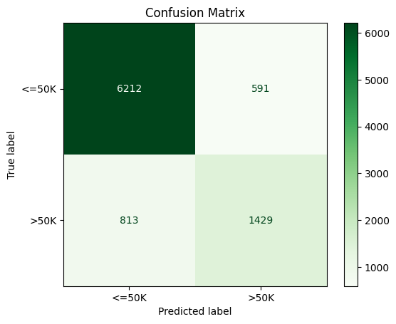

```python
cm = confusion_matrix(y_test, y_pred)

disp = ConfusionMatrixDisplay(
    confusion_matrix=cm,
    display_labels=["<=50K", ">50K"]
)

disp.plot(cmap="Greens")
plt.title("Confusion Matrix")
plt.show()
```

- The trained model was evaluated on the test dataset.
- The classification report provides **Accuracy, Precision, Recall, and F1-score**.
- The confusion matrix shows the number of correctly and incorrectly classified samples.
- Precision, Recall, and F1-score for the **>50K** class are important because it is the minority class.

## 2.5 Why Tabular Data Suits ANN

Structured tabular data is well suited for an Artificial Neural Network (ANN) because each input feature (such as age, education, work hours, and capital gain) can be directly connected to an input neuron. Unlike images or sequential data, tabular datasets do not require specialized architectures like CNNs or RNNs.

The hidden layers of an ANN learn complex relationships between features by combining weighted inputs and applying non-linear activation functions. This enables the model to capture patterns such as the interaction between **age and education** or **working hours and occupation**, which are difficult for simpler models like Logistic Regression to learn.

Therefore, a fully connected Multi-Layer Perceptron (MLP) is a suitable choice for binary classification problems on structured tabular datasets such as the Adult Income dataset.

# Task 3: Activation Functions — Comparison Experiment

## 3.1 Train 4 Models with Different Hidden Activations

```python
# ReLU Model
model_relu = build_ann(input_dim=X_train.shape[1], activation="relu")
history_relu = model_relu.fit(
    X_train, y_train,
    epochs=50,
    batch_size=64,
    validation_split=0.1,
    verbose=1
)

# Tanh Model
model_tanh = build_ann(input_dim=X_train.shape[1], activation="tanh")
history_tanh = model_tanh.fit(
    X_train, y_train,
    epochs=50,
    batch_size=64,
    validation_split=0.1,
    verbose=1
)

# Sigmoid Model
model_sigmoid = build_ann(input_dim=X_train.shape[1], activation="sigmoid")
history_sigmoid = model_sigmoid.fit(
    X_train, y_train,
    epochs=50,
    batch_size=64,
    validation_split=0.1,
    verbose=1
)

# ELU Model
model_elu = build_ann(input_dim=X_train.shape[1], activation="elu")
history_elu = model_elu.fit(
    X_train, y_train,
    epochs=50,
    batch_size=64,
    validation_split=0.1,
    verbose=1
)
```

```
509/509 ━━━━━━━━━━━━━━━━━━━━ 3s 3ms/step - accuracy: 0.8420 - loss: 0.3360 - val_accuracy: 0.8538 - val_loss: 0.3234
509/509 ━━━━━━━━━━━━━━━━━━━━ 1s 3ms/step - accuracy: 0.8533 - loss: 0.3142 - val_accuracy: 0.8530 - val_loss: 0.3248
509/509 ━━━━━━━━━━━━━━━━━━━━ 1s 3ms/step - accuracy: 0.8535 - loss: 0.3105 - val_accuracy: 0.8513 - val_loss: 0.3210
509/509 ━━━━━━━━━━━━━━━━━━━━ 1s 3ms/step - accuracy: 0.8563 - loss: 0.3076 - val_accuracy: 0.8488 - val_loss: 0.3253
509/509 ━━━━━━━━━━━━━━━━━━━━ 1s 3ms/step - accuracy: 0.8578 - loss: 0.3058 - val_accuracy: 0.8507 - val_loss: 0.3172
509/509 ━━━━━━━━━━━━━━━━━━━━ 2s 4ms/step - accuracy: 0.8587 - loss: 0.3022 - val_accuracy: 0.8543 - val_loss: 0.3186
509/509 ━━━━━━━━━━━━━━━━━━━━ 4s 8ms/step - accuracy: 0.8599 - loss: 0.3008 - val_accuracy: 0.8532 - val_loss: 0.3173
509/509 ━━━━━━━━━━━━━━━━━━━━ 2s 4ms/step - accuracy: 0.8619 - loss: 0.2981 - val_accuracy: 0.8507 - val_loss: 0.3185
509/509 ━━━━━━━━━━━━━━━━━━━━ 1s 3ms/step - accuracy: 0.8620 - loss: 0.2949 - val_accuracy: 0.8519 - val_loss: 0.3191
509/509 ━━━━━━━━━━━━━━━━━━━━ 1s 3ms/step - accuracy: 0.8635 - loss: 0.2927 - val_accuracy: 0.8502 - val_loss: 0.3233
509/509 ━━━━━━━━━━━━━━━━━━━━ 1s 3ms/step - accuracy: 0.8646 - loss: 0.2904 - val_accuracy: 0.8488 - val_loss: 0.3201
509/509 ━━━━━━━━━━━━━━━━━━━━ 1s 3ms/step - accuracy: 0.8647 - loss: 0.2886 - val_accuracy: 0.8527 - val_loss: 0.3178
509/509 ━━━━━━━━━━━━━━━━━━━━ 1s 3ms/step - accuracy: 0.8658 - loss: 0.2870 - val_accuracy: 0.8505 - val_loss: 0.3205
509/509 ━━━━━━━━━━━━━━━━━━━━ 2s 4ms/step - accuracy: 0.8666 - loss: 0.2847 - val_accuracy: 0.8563 - val_loss: 0.3189
509/509 ━━━━━━━━━━━━━━━━━━━━ 2s 4ms/step - accuracy: 0.8683 - loss: 0.2815 - val_accuracy: 0.8566 - val_loss: 0.3216
509/509 ━━━━━━━━━━━━━━━━━━━━ 1s 3ms/step - accuracy: 0.8694 - loss: 0.2799 - val_accuracy: 0.8507 - val_loss: 0.3232
509/509 ━━━━━━━━━━━━━━━━━━━━ 1s 3ms/step - accuracy: 0.8697 - loss: 0.2777 - val_accuracy: 0.8513 - val_loss: 0.3227
509/509 ━━━━━━━━━━━━━━━━━━━━ 1s 3ms/step - accuracy: 0.8703 - loss: 0.2756 - val_accuracy: 0.8449 - val_loss: 0.3346
509/509 ━━━━━━━━━━━━━━━━━━━━ 1s 3ms/step - accuracy: 0.8708 - loss: 0.2741 - val_accuracy: 0.8477 - val_loss: 0.3306
509/509 ━━━━━━━━━━━━━━━━━━━━ 1s 3ms/step - accuracy: 0.8729 - loss: 0.2718 - val_accuracy: 0.8521 - val_loss: 0.3300
509/509 ━━━━━━━━━━━━━━━━━━━━ 1s 3ms/step - accuracy: 0.8730 - loss: 0.2707 - val_accuracy: 0.8538 - val_loss: 0.3345
509/509 ━━━━━━━━━━━━━━━━━━━━ 1s 3ms/step - accuracy: 0.8742 - loss: 0.2687 - val_accuracy: 0.8458 - val_loss: 0.3324
509/509 ━━━━━━━━━━━━━━━━━━━━ 2s 3ms/step - accuracy: 0.8749 - loss: 0.2669 - val_accuracy: 0.8496 - val_loss: 0.3319
509/509 ━━━━━━━━━━━━━━━━━━━━ 2s 4ms/step - accuracy: 0.8759 - loss: 0.2651 - val_accuracy: 0.8447 - val_loss: 0.3377
509/509 ━━━━━━━━━━━━━━━━━━━━ 1s 3ms/step - accuracy: 0.8761 - loss: 0.2643 - val_accuracy: 0.8494 - val_loss: 0.3414
509/509 ━━━━━━━━━━━━━━━━━━━━ 1s 3ms/step - accuracy: 0.8771 - loss: 0.2611 - val_accuracy: 0.8510 - val_loss: 0.3440
509/509 ━━━━━━━━━━━━━━━━━━━━ 1s 3ms/step - accuracy: 0.8783 - loss: 0.2604 - val_accuracy: 0.8480 - val_loss: 0.3407
509/509 ━━━━━━━━━━━━━━━━━━━━ 1s 3ms/step - accuracy: 0.8787 - loss: 0.2585 - val_accuracy: 0.8413 - val_loss: 0.3460
509/509 ━━━━━━━━━━━━━━━━━━━━ 1s 3ms/step - accuracy: 0.8806 - loss: 0.2568 - val_accuracy: 0.8458 - val_loss: 0.3491
509/509 ━━━━━━━━━━━━━━━━━━━━ 1s 3ms/step - accuracy: 0.8794 - loss: 0.2559 - val_accuracy: 0.8433 - val_loss: 0.3529
509/509 ━━━━━━━━━━━━━━━━━━━━ 1s 3ms/step - accuracy: 0.8801 - loss: 0.2538 - val_accuracy: 0.8496 - val_loss: 0.3520
509/509 ━━━━━━━━━━━━━━━━━━━━ 2s 4ms/step - accuracy: 0.8818 - loss: 0.2525 - val_accuracy: 0.8469 - val_loss: 0.3576
509/509 ━━━━━━━━━━━━━━━━━━━━ 2s 3ms/step - accuracy: 0.8824 - loss: 0.2515 - val_accuracy: 0.8430 - val_loss: 0.3599
509/509 ━━━━━━━━━━━━━━━━━━━━ 2s 3ms/step - accuracy: 0.8826 - loss: 0.2500 - val_accuracy: 0.8474 - val_loss: 0.3603
509/509 ━━━━━━━━━━━━━━━━━━━━ 3s 5ms/step - accuracy: 0.8826 - loss: 0.2488 - val_accuracy: 0.8455 - val_loss: 0.3626
509/509 ━━━━━━━━━━━━━━━━━━━━ 3s 7ms/step - accuracy: 0.8827 - loss: 0.2480 - val_accuracy: 0.8466 - val_loss: 0.3617
509/509 ━━━━━━━━━━━━━━━━━━━━ 5s 6ms/step - accuracy: 0.8833 - loss: 0.2456 - val_accuracy: 0.8391 - val_loss: 0.3799
509/509 ━━━━━━━━━━━━━━━━━━━━ 4s 4ms/step - accuracy: 0.8859 - loss: 0.2441 - val_accuracy: 0.8441 - val_loss: 0.3734
509/509 ━━━━━━━━━━━━━━━━━━━━ 2s 3ms/step - accuracy: 0.8866 - loss: 0.2422 - val_accuracy: 0.8505 - val_loss: 0.3688
509/509 ━━━━━━━━━━━━━━━━━━━━ 1s 3ms/step - accuracy: 0.8863 - loss: 0.2422 - val_accuracy: 0.8441 - val_loss: 0.3754
509/509 ━━━━━━━━━━━━━━━━━━━━ 1s 3ms/step - accuracy: 0.8885 - loss: 0.2398 - val_accuracy: 0.8460 - val_loss: 0.3844
509/509 ━━━━━━━━━━━━━━━━━━━━ 2s 4ms/step - accuracy: 0.8866 - loss: 0.2391 - val_accuracy: 0.8463 - val_loss: 0.3770
509/509 ━━━━━━━━━━━━━━━━━━━━ 2s 4ms/step - accuracy: 0.8876 - loss: 0.2370 - val_accuracy: 0.8419 - val_loss: 0.3826
509/509 ━━━━━━━━━━━━━━━━━━━━ 2s 3ms/step - accuracy: 0.8892 - loss: 0.2361 - val_accuracy: 0.8430 - val_loss: 0.3908
509/509 ━━━━━━━━━━━━━━━━━━━━ 1s 3ms/step - accuracy: 0.8893 - loss: 0.2359 - val_accuracy: 0.8436 - val_loss: 0.3868
509/509 ━━━━━━━━━━━━━━━━━━━━ 1s 3ms/step - accuracy: 0.8885 - loss: 0.2347 - val_accuracy: 0.8419 - val_loss: 0.3956
509/509 ━━━━━━━━━━━━━━━━━━━━ 1s 3ms/step - accuracy: 0.8901 - loss: 0.2324 - val_accuracy: 0.8427 - val_loss: 0.3971
509/509 ━━━━━━━━━━━━━━━━━━━━ 1s 3ms/step - accuracy: 0.8903 - loss: 0.2319 - val_accuracy: 0.8425 - val_loss: 0.3915
509/509 ━━━━━━━━━━━━━━━━━━━━ 1s 3ms/step - accuracy: 0.8916 - loss: 0.2310 - val_accuracy: 0.8416 - val_loss: 0.4002
509/509 ━━━━━━━━━━━━━━━━━━━━ 2s 4ms/step - accuracy: 0.8919 - loss: 0.2295 - val_accuracy: 0.8455 - val_loss: 0.3929
```

```
509/509 ━━━━━━━━━━━━━━━━━━━━ 3s 3ms/step - accuracy: 0.8441 - loss: 0.3366 - val_accuracy: 0.8416 - val_loss: 0.3331
509/509 ━━━━━━━━━━━━━━━━━━━━ 3s 4ms/step - accuracy: 0.8484 - loss: 0.3224 - val_accuracy: 0.8460 - val_loss: 0.3262
509/509 ━━━━━━━━━━━━━━━━━━━━ 1s 3ms/step - accuracy: 0.8510 - loss: 0.3176 - val_accuracy: 0.8477 - val_loss: 0.3240
509/509 ━━━━━━━━━━━━━━━━━━━━ 1s 3ms/step - accuracy: 0.8517 - loss: 0.3149 - val_accuracy: 0.8543 - val_loss: 0.3215
509/509 ━━━━━━━━━━━━━━━━━━━━ 1s 3ms/step - accuracy: 0.8535 - loss: 0.3128 - val_accuracy: 0.8483 - val_loss: 0.3215
509/509 ━━━━━━━━━━━━━━━━━━━━ 2s 3ms/step - accuracy: 0.8543 - loss: 0.3093 - val_accuracy: 0.8519 - val_loss: 0.3234
509/509 ━━━━━━━━━━━━━━━━━━━━ 2s 4ms/step - accuracy: 0.8561 - loss: 0.3075 - val_accuracy: 0.8557 - val_loss: 0.3197
509/509 ━━━━━━━━━━━━━━━━━━━━ 2s 3ms/step - accuracy: 0.8566 - loss: 0.3058 - val_accuracy: 0.8541 - val_loss: 0.3170
509/509 ━━━━━━━━━━━━━━━━━━━━ 1s 3ms/step - accuracy: 0.8573 - loss: 0.3042 - val_accuracy: 0.8560 - val_loss: 0.3150
509/509 ━━━━━━━━━━━━━━━━━━━━ 1s 3ms/step - accuracy: 0.8584 - loss: 0.3024 - val_accuracy: 0.8488 - val_loss: 0.3222
509/509 ━━━━━━━━━━━━━━━━━━━━ 1s 3ms/step - accuracy: 0.8591 - loss: 0.3011 - val_accuracy: 0.8541 - val_loss: 0.3152
509/509 ━━━━━━━━━━━━━━━━━━━━ 1s 3ms/step - accuracy: 0.8583 - loss: 0.2998 - val_accuracy: 0.8590 - val_loss: 0.3149
509/509 ━━━━━━━━━━━━━━━━━━━━ 1s 3ms/step - accuracy: 0.8614 - loss: 0.2977 - val_accuracy: 0.8612 - val_loss: 0.3167
509/509 ━━━━━━━━━━━━━━━━━━━━ 1s 3ms/step - accuracy: 0.8615 - loss: 0.2976 - val_accuracy: 0.8546 - val_loss: 0.3144
509/509 ━━━━━━━━━━━━━━━━━━━━ 2s 4ms/step - accuracy: 0.8613 - loss: 0.2961 - val_accuracy: 0.8582 - val_loss: 0.3136
509/509 ━━━━━━━━━━━━━━━━━━━━ 2s 5ms/step - accuracy: 0.8626 - loss: 0.2950 - val_accuracy: 0.8563 - val_loss: 0.3143
509/509 ━━━━━━━━━━━━━━━━━━━━ 1s 3ms/step - accuracy: 0.8626 - loss: 0.2940 - val_accuracy: 0.8588 - val_loss: 0.3155
509/509 ━━━━━━━━━━━━━━━━━━━━ 1s 3ms/step - accuracy: 0.8632 - loss: 0.2932 - val_accuracy: 0.8510 - val_loss: 0.3160
509/509 ━━━━━━━━━━━━━━━━━━━━ 1s 3ms/step - accuracy: 0.8631 - loss: 0.2920 - val_accuracy: 0.8588 - val_loss: 0.3147
509/509 ━━━━━━━━━━━━━━━━━━━━ 1s 3ms/step - accuracy: 0.8643 - loss: 0.2907 - val_accuracy: 0.8568 - val_loss: 0.3151
509/509 ━━━━━━━━━━━━━━━━━━━━ 1s 3ms/step - accuracy: 0.8644 - loss: 0.2895 - val_accuracy: 0.8585 - val_loss: 0.3136
509/509 ━━━━━━━━━━━━━━━━━━━━ 1s 3ms/step - accuracy: 0.8658 - loss: 0.2886 - val_accuracy: 0.8566 - val_loss: 0.3165
509/509 ━━━━━━━━━━━━━━━━━━━━ 1s 3ms/step - accuracy: 0.8654 - loss: 0.2879 - val_accuracy: 0.8552 - val_loss: 0.3203
509/509 ━━━━━━━━━━━━━━━━━━━━ 2s 4ms/step - accuracy: 0.8659 - loss: 0.2862 - val_accuracy: 0.8563 - val_loss: 0.3161
509/509 ━━━━━━━━━━━━━━━━━━━━ 2s 4ms/step - accuracy: 0.8671 - loss: 0.2854 - val_accuracy: 0.8596 - val_loss: 0.3158
509/509 ━━━━━━━━━━━━━━━━━━━━ 1s 3ms/step - accuracy: 0.8683 - loss: 0.2839 - val_accuracy: 0.8499 - val_loss: 0.3220
509/509 ━━━━━━━━━━━━━━━━━━━━ 1s 3ms/step - accuracy: 0.8677 - loss: 0.2832 - val_accuracy: 0.8588 - val_loss: 0.3178
509/509 ━━━━━━━━━━━━━━━━━━━━ 1s 3ms/step - accuracy: 0.8681 - loss: 0.2819 - val_accuracy: 0.8612 - val_loss: 0.3194
509/509 ━━━━━━━━━━━━━━━━━━━━ 1s 3ms/step - accuracy: 0.8685 - loss: 0.2814 - val_accuracy: 0.8568 - val_loss: 0.3151
509/509 ━━━━━━━━━━━━━━━━━━━━ 2s 3ms/step - accuracy: 0.8692 - loss: 0.2799 - val_accuracy: 0.8549 - val_loss: 0.3216
509/509 ━━━━━━━━━━━━━━━━━━━━ 3s 3ms/step - accuracy: 0.8694 - loss: 0.2797 - val_accuracy: 0.8618 - val_loss: 0.3171
509/509 ━━━━━━━━━━━━━━━━━━━━ 3s 6ms/step - accuracy: 0.8705 - loss: 0.2787 - val_accuracy: 0.8621 - val_loss: 0.3162
509/509 ━━━━━━━━━━━━━━━━━━━━ 2s 4ms/step - accuracy: 0.8712 - loss: 0.2775 - val_accuracy: 0.8579 - val_loss: 0.3192
509/509 ━━━━━━━━━━━━━━━━━━━━ 1s 3ms/step - accuracy: 0.8721 - loss: 0.2759 - val_accuracy: 0.8568 - val_loss: 0.3194
509/509 ━━━━━━━━━━━━━━━━━━━━ 1s 3ms/step - accuracy: 0.8728 - loss: 0.2752 - val_accuracy: 0.8541 - val_loss: 0.3209
509/509 ━━━━━━━━━━━━━━━━━━━━ 1s 3ms/step - accuracy: 0.8728 - loss: 0.2740 - val_accuracy: 0.8588 - val_loss: 0.3184
509/509 ━━━━━━━━━━━━━━━━━━━━ 1s 3ms/step - accuracy: 0.8732 - loss: 0.2737 - val_accuracy: 0.8593 - val_loss: 0.3194
509/509 ━━━━━━━━━━━━━━━━━━━━ 1s 3ms/step - accuracy: 0.8730 - loss: 0.2721 - val_accuracy: 0.8554 - val_loss: 0.3209
509/509 ━━━━━━━━━━━━━━━━━━━━ 1s 3ms/step - accuracy: 0.8742 - loss: 0.2719 - val_accuracy: 0.8499 - val_loss: 0.3241
509/509 ━━━━━━━━━━━━━━━━━━━━ 2s 4ms/step - accuracy: 0.8737 - loss: 0.2707 - val_accuracy: 0.8554 - val_loss: 0.3205
509/509 ━━━━━━━━━━━━━━━━━━━━ 2s 3ms/step - accuracy: 0.8745 - loss: 0.2702 - val_accuracy: 0.8560 - val_loss: 0.3204
509/509 ━━━━━━━━━━━━━━━━━━━━ 1s 3ms/step - accuracy: 0.8750 - loss: 0.2687 - val_accuracy: 0.8554 - val_loss: 0.3263
509/509 ━━━━━━━━━━━━━━━━━━━━ 1s 3ms/step - accuracy: 0.8751 - loss: 0.2680 - val_accuracy: 0.8607 - val_loss: 0.3253
509/509 ━━━━━━━━━━━━━━━━━━━━ 1s 3ms/step - accuracy: 0.8756 - loss: 0.2674 - val_accuracy: 0.8554 - val_loss: 0.3253
509/509 ━━━━━━━━━━━━━━━━━━━━ 1s 3ms/step - accuracy: 0.8773 - loss: 0.2660 - val_accuracy: 0.8574 - val_loss: 0.3271
509/509 ━━━━━━━━━━━━━━━━━━━━ 1s 3ms/step - accuracy: 0.8772 - loss: 0.2653 - val_accuracy: 0.8554 - val_loss: 0.3210
509/509 ━━━━━━━━━━━━━━━━━━━━ 2s 4ms/step - accuracy: 0.8767 - loss: 0.2646 - val_accuracy: 0.8549 - val_loss: 0.3227
509/509 ━━━━━━━━━━━━━━━━━━━━ 2s 4ms/step - accuracy: 0.8777 - loss: 0.2632 - val_accuracy: 0.8546 - val_loss: 0.3287
509/509 ━━━━━━━━━━━━━━━━━━━━ 2s 4ms/step - accuracy: 0.8772 - loss: 0.2621 - val_accuracy: 0.8554 - val_loss: 0.3276
509/509 ━━━━━━━━━━━━━━━━━━━━ 1s 3ms/step - accuracy: 0.8782 - loss: 0.2613 - val_accuracy: 0.8554 - val_loss: 0.3253
```

```
509/509 ━━━━━━━━━━━━━━━━━━━━ 3s 3ms/step - accuracy: 0.8168 - loss: 0.3874 - val_accuracy: 0.8458 - val_loss: 0.3367
509/509 ━━━━━━━━━━━━━━━━━━━━ 2s 3ms/step - accuracy: 0.8462 - loss: 0.3294 - val_accuracy: 0.8474 - val_loss: 0.3317
509/509 ━━━━━━━━━━━━━━━━━━━━ 2s 3ms/step - accuracy: 0.8481 - loss: 0.3271 - val_accuracy: 0.8474 - val_loss: 0.3307
509/509 ━━━━━━━━━━━━━━━━━━━━ 2s 3ms/step - accuracy: 0.8489 - loss: 0.3254 - val_accuracy: 0.8530 - val_loss: 0.3286
509/509 ━━━━━━━━━━━━━━━━━━━━ 2s 4ms/step - accuracy: 0.8486 - loss: 0.3246 - val_accuracy: 0.8469 - val_loss: 0.3305
509/509 ━━━━━━━━━━━━━━━━━━━━ 2s 3ms/step - accuracy: 0.8471 - loss: 0.3235 - val_accuracy: 0.8472 - val_loss: 0.3281
509/509 ━━━━━━━━━━━━━━━━━━━━ 2s 3ms/step - accuracy: 0.8500 - loss: 0.3217 - val_accuracy: 0.8513 - val_loss: 0.3261
509/509 ━━━━━━━━━━━━━━━━━━━━ 2s 4ms/step - accuracy: 0.8488 - loss: 0.3209 - val_accuracy: 0.8519 - val_loss: 0.3249
509/509 ━━━━━━━━━━━━━━━━━━━━ 1s 3ms/step - accuracy: 0.8487 - loss: 0.3197 - val_accuracy: 0.8513 - val_loss: 0.3252
509/509 ━━━━━━━━━━━━━━━━━━━━ 1s 3ms/step - accuracy: 0.8494 - loss: 0.3186 - val_accuracy: 0.8494 - val_loss: 0.3265
509/509 ━━━━━━━━━━━━━━━━━━━━ 1s 3ms/step - accuracy: 0.8500 - loss: 0.3179 - val_accuracy: 0.8532 - val_loss: 0.3223
509/509 ━━━━━━━━━━━━━━━━━━━━ 2s 3ms/step - accuracy: 0.8497 - loss: 0.3164 - val_accuracy: 0.8488 - val_loss: 0.3262
509/509 ━━━━━━━━━━━━━━━━━━━━ 3s 4ms/step - accuracy: 0.8508 - loss: 0.3156 - val_accuracy: 0.8516 - val_loss: 0.3211
509/509 ━━━━━━━━━━━━━━━━━━━━ 1s 3ms/step - accuracy: 0.8503 - loss: 0.3159 - val_accuracy: 0.8527 - val_loss: 0.3214
509/509 ━━━━━━━━━━━━━━━━━━━━ 1s 3ms/step - accuracy: 0.8510 - loss: 0.3145 - val_accuracy: 0.8491 - val_loss: 0.3295
509/509 ━━━━━━━━━━━━━━━━━━━━ 2s 3ms/step - accuracy: 0.8514 - loss: 0.3142 - val_accuracy: 0.8499 - val_loss: 0.3222
509/509 ━━━━━━━━━━━━━━━━━━━━ 1s 3ms/step - accuracy: 0.8528 - loss: 0.3135 - val_accuracy: 0.8538 - val_loss: 0.3203
509/509 ━━━━━━━━━━━━━━━━━━━━ 1s 3ms/step - accuracy: 0.8532 - loss: 0.3127 - val_accuracy: 0.8516 - val_loss: 0.3227
509/509 ━━━━━━━━━━━━━━━━━━━━ 2s 3ms/step - accuracy: 0.8519 - loss: 0.3131 - val_accuracy: 0.8499 - val_loss: 0.3211
509/509 ━━━━━━━━━━━━━━━━━━━━ 2s 4ms/step - accuracy: 0.8519 - loss: 0.3129 - val_accuracy: 0.8494 - val_loss: 0.3202
509/509 ━━━━━━━━━━━━━━━━━━━━ 2s 4ms/step - accuracy: 0.8521 - loss: 0.3128 - val_accuracy: 0.8519 - val_loss: 0.3212
509/509 ━━━━━━━━━━━━━━━━━━━━ 1s 3ms/step - accuracy: 0.8521 - loss: 0.3121 - val_accuracy: 0.8513 - val_loss: 0.3201
509/509 ━━━━━━━━━━━━━━━━━━━━ 1s 3ms/step - accuracy: 0.8523 - loss: 0.3120 - val_accuracy: 0.8552 - val_loss: 0.3222
509/509 ━━━━━━━━━━━━━━━━━━━━ 1s 3ms/step - accuracy: 0.8530 - loss: 0.3114 - val_accuracy: 0.8532 - val_loss: 0.3214
509/509 ━━━━━━━━━━━━━━━━━━━━ 1s 3ms/step - accuracy: 0.8533 - loss: 0.3117 - val_accuracy: 0.8554 - val_loss: 0.3225
509/509 ━━━━━━━━━━━━━━━━━━━━ 1s 3ms/step - accuracy: 0.8535 - loss: 0.3113 - val_accuracy: 0.8505 - val_loss: 0.3202
509/509 ━━━━━━━━━━━━━━━━━━━━ 2s 3ms/step - accuracy: 0.8528 - loss: 0.3112 - val_accuracy: 0.8502 - val_loss: 0.3206
509/509 ━━━━━━━━━━━━━━━━━━━━ 2s 4ms/step - accuracy: 0.8535 - loss: 0.3105 - val_accuracy: 0.8546 - val_loss: 0.3211
509/509 ━━━━━━━━━━━━━━━━━━━━ 2s 5ms/step - accuracy: 0.8530 - loss: 0.3103 - val_accuracy: 0.8516 - val_loss: 0.3209
509/509 ━━━━━━━━━━━━━━━━━━━━ 2s 3ms/step - accuracy: 0.8528 - loss: 0.3103 - val_accuracy: 0.8513 - val_loss: 0.3204
509/509 ━━━━━━━━━━━━━━━━━━━━ 1s 3ms/step - accuracy: 0.8536 - loss: 0.3097 - val_accuracy: 0.8513 - val_loss: 0.3202
509/509 ━━━━━━━━━━━━━━━━━━━━ 2s 3ms/step - accuracy: 0.8541 - loss: 0.3098 - val_accuracy: 0.8510 - val_loss: 0.3204
509/509 ━━━━━━━━━━━━━━━━━━━━ 1s 3ms/step - accuracy: 0.8542 - loss: 0.3094 - val_accuracy: 0.8541 - val_loss: 0.3210
509/509 ━━━━━━━━━━━━━━━━━━━━ 1s 3ms/step - accuracy: 0.8538 - loss: 0.3090 - val_accuracy: 0.8527 - val_loss: 0.3211
509/509 ━━━━━━━━━━━━━━━━━━━━ 1s 3ms/step - accuracy: 0.8544 - loss: 0.3087 - val_accuracy: 0.8519 - val_loss: 0.3230
509/509 ━━━━━━━━━━━━━━━━━━━━ 1s 3ms/step - accuracy: 0.8543 - loss: 0.3085 - val_accuracy: 0.8549 - val_loss: 0.3210
509/509 ━━━━━━━━━━━━━━━━━━━━ 2s 4ms/step - accuracy: 0.8548 - loss: 0.3081 - val_accuracy: 0.8535 - val_loss: 0.3194
509/509 ━━━━━━━━━━━━━━━━━━━━ 2s 3ms/step - accuracy: 0.8551 - loss: 0.3077 - val_accuracy: 0.8532 - val_loss: 0.3200
509/509 ━━━━━━━━━━━━━━━━━━━━ 1s 3ms/step - accuracy: 0.8546 - loss: 0.3076 - val_accuracy: 0.8535 - val_loss: 0.3214
509/509 ━━━━━━━━━━━━━━━━━━━━ 3s 3ms/step - accuracy: 0.8557 - loss: 0.3072 - val_accuracy: 0.8543 - val_loss: 0.3206
509/509 ━━━━━━━━━━━━━━━━━━━━ 1s 3ms/step - accuracy: 0.8558 - loss: 0.3065 - val_accuracy: 0.8474 - val_loss: 0.3223
509/509 ━━━━━━━━━━━━━━━━━━━━ 1s 3ms/step - accuracy: 0.8556 - loss: 0.3063 - val_accuracy: 0.8527 - val_loss: 0.3180
509/509 ━━━━━━━━━━━━━━━━━━━━ 1s 3ms/step - accuracy: 0.8551 - loss: 0.3060 - val_accuracy: 0.8554 - val_loss: 0.3181
509/509 ━━━━━━━━━━━━━━━━━━━━ 4s 7ms/step - accuracy: 0.8548 - loss: 0.3055 - val_accuracy: 0.8543 - val_loss: 0.3172
509/509 ━━━━━━━━━━━━━━━━━━━━ 2s 4ms/step - accuracy: 0.8564 - loss: 0.3050 - val_accuracy: 0.8530 - val_loss: 0.3178
509/509 ━━━━━━━━━━━━━━━━━━━━ 1s 3ms/step - accuracy: 0.8557 - loss: 0.3048 - val_accuracy: 0.8563 - val_loss: 0.3172
509/509 ━━━━━━━━━━━━━━━━━━━━ 1s 3ms/step - accuracy: 0.8560 - loss: 0.3046 - val_accuracy: 0.8571 - val_loss: 0.3184
509/509 ━━━━━━━━━━━━━━━━━━━━ 1s 3ms/step - accuracy: 0.8565 - loss: 0.3039 - val_accuracy: 0.8549 - val_loss: 0.3173
509/509 ━━━━━━━━━━━━━━━━━━━━ 1s 3ms/step - accuracy: 0.8576 - loss: 0.3033 - val_accuracy: 0.8563 - val_loss: 0.3160
509/509 ━━━━━━━━━━━━━━━━━━━━ 1s 3ms/step - accuracy: 0.8579 - loss: 0.3029 - val_accuracy: 0.8541 - val_loss: 0.3159
```

```
509/509 ━━━━━━━━━━━━━━━━━━━━ 3s 4ms/step - accuracy: 0.8441 - loss: 0.3356 - val_accuracy: 0.8477 - val_loss: 0.3289
509/509 ━━━━━━━━━━━━━━━━━━━━ 2s 4ms/step - accuracy: 0.8496 - loss: 0.3205 - val_accuracy: 0.8502 - val_loss: 0.3242
509/509 ━━━━━━━━━━━━━━━━━━━━ 2s 3ms/step - accuracy: 0.8516 - loss: 0.3174 - val_accuracy: 0.8491 - val_loss: 0.3224
509/509 ━━━━━━━━━━━━━━━━━━━━ 1s 3ms/step - accuracy: 0.8520 - loss: 0.3162 - val_accuracy: 0.8524 - val_loss: 0.3231
509/509 ━━━━━━━━━━━━━━━━━━━━ 1s 3ms/step - accuracy: 0.8526 - loss: 0.3151 - val_accuracy: 0.8485 - val_loss: 0.3232
509/509 ━━━━━━━━━━━━━━━━━━━━ 2s 3ms/step - accuracy: 0.8539 - loss: 0.3146 - val_accuracy: 0.8546 - val_loss: 0.3216
509/509 ━━━━━━━━━━━━━━━━━━━━ 1s 3ms/step - accuracy: 0.8534 - loss: 0.3139 - val_accuracy: 0.8502 - val_loss: 0.3218
509/509 ━━━━━━━━━━━━━━━━━━━━ 2s 3ms/step - accuracy: 0.8539 - loss: 0.3120 - val_accuracy: 0.8527 - val_loss: 0.3226
509/509 ━━━━━━━━━━━━━━━━━━━━ 2s 4ms/step - accuracy: 0.8535 - loss: 0.3110 - val_accuracy: 0.8546 - val_loss: 0.3212
509/509 ━━━━━━━━━━━━━━━━━━━━ 2s 4ms/step - accuracy: 0.8552 - loss: 0.3096 - val_accuracy: 0.8527 - val_loss: 0.3198
509/509 ━━━━━━━━━━━━━━━━━━━━ 2s 3ms/step - accuracy: 0.8571 - loss: 0.3085 - val_accuracy: 0.8532 - val_loss: 0.3222
509/509 ━━━━━━━━━━━━━━━━━━━━ 1s 3ms/step - accuracy: 0.8571 - loss: 0.3077 - val_accuracy: 0.8513 - val_loss: 0.3205
509/509 ━━━━━━━━━━━━━━━━━━━━ 1s 3ms/step - accuracy: 0.8576 - loss: 0.3066 - val_accuracy: 0.8563 - val_loss: 0.3199
509/509 ━━━━━━━━━━━━━━━━━━━━ 1s 3ms/step - accuracy: 0.8567 - loss: 0.3063 - val_accuracy: 0.8541 - val_loss: 0.3206
509/509 ━━━━━━━━━━━━━━━━━━━━ 1s 3ms/step - accuracy: 0.8578 - loss: 0.3052 - val_accuracy: 0.8582 - val_loss: 0.3190
509/509 ━━━━━━━━━━━━━━━━━━━━ 2s 3ms/step - accuracy: 0.8578 - loss: 0.3039 - val_accuracy: 0.8552 - val_loss: 0.3205
509/509 ━━━━━━━━━━━━━━━━━━━━ 2s 4ms/step - accuracy: 0.8587 - loss: 0.3036 - val_accuracy: 0.8513 - val_loss: 0.3222
509/509 ━━━━━━━━━━━━━━━━━━━━ 2s 4ms/step - accuracy: 0.8596 - loss: 0.3029 - val_accuracy: 0.8563 - val_loss: 0.3183
509/509 ━━━━━━━━━━━━━━━━━━━━ 1s 3ms/step - accuracy: 0.8585 - loss: 0.3021 - val_accuracy: 0.8554 - val_loss: 0.3190
509/509 ━━━━━━━━━━━━━━━━━━━━ 1s 3ms/step - accuracy: 0.8588 - loss: 0.3014 - val_accuracy: 0.8521 - val_loss: 0.3195
509/509 ━━━━━━━━━━━━━━━━━━━━ 1s 3ms/step - accuracy: 0.8605 - loss: 0.3006 - val_accuracy: 0.8532 - val_loss: 0.3196
509/509 ━━━━━━━━━━━━━━━━━━━━ 1s 3ms/step - accuracy: 0.8604 - loss: 0.3001 - val_accuracy: 0.8577 - val_loss: 0.3216
509/509 ━━━━━━━━━━━━━━━━━━━━ 1s 3ms/step - accuracy: 0.8594 - loss: 0.2998 - val_accuracy: 0.8524 - val_loss: 0.3187
509/509 ━━━━━━━━━━━━━━━━━━━━ 1s 3ms/step - accuracy: 0.8623 - loss: 0.2985 - val_accuracy: 0.8588 - val_loss: 0.3163
509/509 ━━━━━━━━━━━━━━━━━━━━ 2s 3ms/step - accuracy: 0.8611 - loss: 0.2980 - val_accuracy: 0.8585 - val_loss: 0.3195
509/509 ━━━━━━━━━━━━━━━━━━━━ 2s 4ms/step - accuracy: 0.8622 - loss: 0.2980 - val_accuracy: 0.8566 - val_loss: 0.3174
509/509 ━━━━━━━━━━━━━━━━━━━━ 2s 3ms/step - accuracy: 0.8623 - loss: 0.2970 - val_accuracy: 0.8621 - val_loss: 0.3166
509/509 ━━━━━━━━━━━━━━━━━━━━ 1s 3ms/step - accuracy: 0.8618 - loss: 0.2969 - val_accuracy: 0.8546 - val_loss: 0.3189
509/509 ━━━━━━━━━━━━━━━━━━━━ 1s 3ms/step - accuracy: 0.8625 - loss: 0.2960 - val_accuracy: 0.8519 - val_loss: 0.3172
509/509 ━━━━━━━━━━━━━━━━━━━━ 2s 3ms/step - accuracy: 0.8626 - loss: 0.2954 - val_accuracy: 0.8524 - val_loss: 0.3179
509/509 ━━━━━━━━━━━━━━━━━━━━ 1s 3ms/step - accuracy: 0.8629 - loss: 0.2947 - val_accuracy: 0.8585 - val_loss: 0.3202
509/509 ━━━━━━━━━━━━━━━━━━━━ 1s 3ms/step - accuracy: 0.8623 - loss: 0.2950 - val_accuracy: 0.8521 - val_loss: 0.3197
509/509 ━━━━━━━━━━━━━━━━━━━━ 1s 3ms/step - accuracy: 0.8634 - loss: 0.2939 - val_accuracy: 0.8571 - val_loss: 0.3177
509/509 ━━━━━━━━━━━━━━━━━━━━ 2s 4ms/step - accuracy: 0.8643 - loss: 0.2936 - val_accuracy: 0.8519 - val_loss: 0.3177
509/509 ━━━━━━━━━━━━━━━━━━━━ 3s 5ms/step - accuracy: 0.8644 - loss: 0.2928 - val_accuracy: 0.8527 - val_loss: 0.3191
509/509 ━━━━━━━━━━━━━━━━━━━━ 5s 5ms/step - accuracy: 0.8636 - loss: 0.2926 - val_accuracy: 0.8560 - val_loss: 0.3157
509/509 ━━━━━━━━━━━━━━━━━━━━ 3s 6ms/step - accuracy: 0.8650 - loss: 0.2921 - val_accuracy: 0.8577 - val_loss: 0.3196
509/509 ━━━━━━━━━━━━━━━━━━━━ 5s 6ms/step - accuracy: 0.8655 - loss: 0.2913 - val_accuracy: 0.8568 - val_loss: 0.3153
509/509 ━━━━━━━━━━━━━━━━━━━━ 2s 4ms/step - accuracy: 0.8653 - loss: 0.2911 - val_accuracy: 0.8563 - val_loss: 0.3212
509/509 ━━━━━━━━━━━━━━━━━━━━ 2s 3ms/step - accuracy: 0.8665 - loss: 0.2908 - val_accuracy: 0.8571 - val_loss: 0.3183
509/509 ━━━━━━━━━━━━━━━━━━━━ 1s 3ms/step - accuracy: 0.8650 - loss: 0.2902 - val_accuracy: 0.8579 - val_loss: 0.3192
509/509 ━━━━━━━━━━━━━━━━━━━━ 1s 3ms/step - accuracy: 0.8651 - loss: 0.2899 - val_accuracy: 0.8524 - val_loss: 0.3172
509/509 ━━━━━━━━━━━━━━━━━━━━ 2s 3ms/step - accuracy: 0.8673 - loss: 0.2888 - val_accuracy: 0.8546 - val_loss: 0.3179
509/509 ━━━━━━━━━━━━━━━━━━━━ 2s 4ms/step - accuracy: 0.8655 - loss: 0.2891 - val_accuracy: 0.8557 - val_loss: 0.3232
509/509 ━━━━━━━━━━━━━━━━━━━━ 2s 4ms/step - accuracy: 0.8667 - loss: 0.2879 - val_accuracy: 0.8563 - val_loss: 0.3205
509/509 ━━━━━━━━━━━━━━━━━━━━ 1s 3ms/step - accuracy: 0.8660 - loss: 0.2875 - val_accuracy: 0.8577 - val_loss: 0.3186
509/509 ━━━━━━━━━━━━━━━━━━━━ 1s 3ms/step - accuracy: 0.8668 - loss: 0.2868 - val_accuracy: 0.8590 - val_loss: 0.3196
509/509 ━━━━━━━━━━━━━━━━━━━━ 1s 3ms/step - accuracy: 0.8665 - loss: 0.2866 - val_accuracy: 0.8571 - val_loss: 0.3186
509/509 ━━━━━━━━━━━━━━━━━━━━ 2s 3ms/step - accuracy: 0.8667 - loss: 0.2859 - val_accuracy: 0.8549 - val_loss: 0.3259
509/509 ━━━━━━━━━━━━━━━━━━━━ 1s 3ms/step - accuracy: 0.8671 - loss: 0.2853 - val_accuracy: 0.8560 - val_loss: 0.3207
```

- Four ANN models were trained using different hidden layer activation functions: **ReLU, Tanh, Sigmoid, and ELU**.
- All other parameters were kept the same to ensure a fair comparison.

## 3.2 Activation Comparison – 4-Panel Plot

```
283/283 ━━━━━━━━━━━━━━━━━━━━ 1s 2ms/step
283/283 ━━━━━━━━━━━━━━━━━━━━ 1s 2ms/step
283/283 ━━━━━━━━━━━━━━━━━━━━ 0s 2ms/step
283/283 ━━━━━━━━━━━━━━━━━━━━ 1s 2ms/step
```

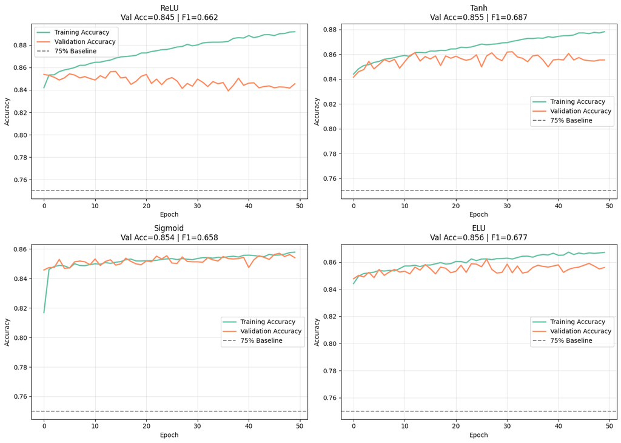

```python
from sklearn.metrics import f1_score

histories = {
    "ReLU": (history_relu, model_relu),
    "Tanh": (history_tanh, model_tanh),
    "Sigmoid": (history_sigmoid, model_sigmoid),
    "ELU": (history_elu, model_elu)
}

plt.figure(figsize=(14,10))

for i, (name, (history, model)) in enumerate(histories.items(), start=1):

    y_pred = (model.predict(X_test).flatten() > 0.5).astype(int)

    f1 = f1_score(y_test, y_pred)
    val_acc = history.history["val_accuracy"][-1]

    plt.subplot(2,2,i)

    # Training Accuracy
    plt.plot(
        history.history["accuracy"],
        color="#66C2A5",
        linewidth=2,
        label="Training Accuracy"
    )

    # Validation Accuracy
    plt.plot(
        history.history["val_accuracy"],
        color="#FC8D62",
        linewidth=2,
        label="Validation Accuracy"
    )

    # Baseline
    plt.axhline(
        y=0.75,
        linestyle="--",
        color="gray",
        label="75% Baseline"
    )

    plt.title(f"{name}\nVal Acc={val_acc:.3f} | F1={f1:.3f}")
    plt.xlabel("Epoch")
    plt.ylabel("Accuracy")
    plt.grid(alpha=0.3)
    plt.legend()

plt.tight_layout()
plt.show()
```

- The training and validation accuracy curves of all four activation functions were compared.
- The dashed horizontal line at **75%** represents the majority-class baseline accuracy.

## 3.3 Dead Neuron Check – ReLU

```
Dead Fraction: 0.6196
```

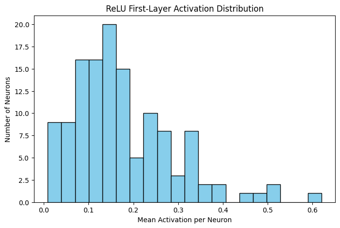

```python
from tensorflow.keras.models import Model

# Ensure the model is built explicitly if its input property is not readily available
model_relu.build(input_shape=(None, X_train.shape[1]))

intermediate = Model(
    inputs=model_relu.layers[0].input, # Changed to access input via the first layer
    outputs=model_relu.layers[0].output
)

activations = intermediate.predict(X_test[:500], verbose=0)

dead_fraction = np.mean(activations == 0)

print(f"Dead Fraction: {dead_fraction:.4f}")

mean_activation = activations.mean(axis=0)

# Plot Histogram
plt.figure(figsize=(8,5))
plt.hist(mean_activation, bins=20, edgecolor="black", color="skyblue")
plt.title("ReLU First-Layer Activation Distribution")
plt.xlabel("Mean Activation per Neuron")
plt.ylabel("Number of Neurons")
plt.show()
```

- The activations of the first hidden layer were extracted for **500 test samples**.
- The **dead fraction** measures the percentage of ReLU outputs that are exactly **0**.

### Why ELU Avoids Dead Neurons

ReLU outputs **0** for all negative input values. If a neuron keeps producing zero, it stops updating its weights because its gradient becomes zero. This problem is called the **Dead Neuron Problem**.

The **ELU (Exponential Linear Unit)** activation function reduces this problem by producing small negative outputs for negative inputs instead of zero:

[ ELU(x)= \begin{cases} x, & x>0 \\ \alpha(e^x-1), & x\le0 \end{cases} ]

Because ELU provides a non-zero gradient for negative inputs, neurons continue to learn during training. This keeps the gradient flowing and reduces the number of dead neurons, often leading to better convergence than ReLU.

## 3.4 Gradient Flow Check – Sigmoid Hidden Layers

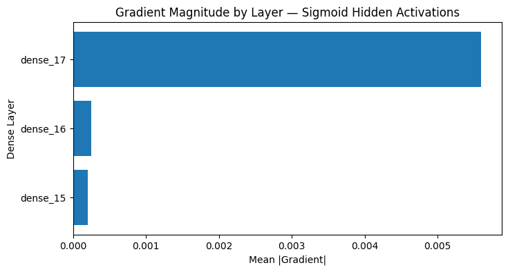

```
dense_15: 0.000206
dense_16: 0.000244
dense_17: 0.005600
```

```python
X_batch = tf.convert_to_tensor(X_train[:64], dtype=tf.float32)
y_batch = tf.convert_to_tensor(y_train[:64].values.reshape(-1, 1), dtype=tf.float32)

with tf.GradientTape() as tape:
    predictions = model_sigmoid(X_batch, training=True)
    loss = tf.keras.losses.binary_crossentropy(y_batch, predictions)
    loss = tf.reduce_mean(loss)

gradients = tape.gradient(loss, model_sigmoid.trainable_weights)

layer_names = []
gradient_values = []

# Create a list of (weight_variable, gradient_tensor) pairs for easy lookup
weight_grad_pairs = list(zip(model_sigmoid.trainable_weights, gradients))

for layer in model_sigmoid.layers:
    if isinstance(layer, tf.keras.layers.Dense):
        kernel_weights_var = layer.kernel # This is the tf.Variable for the kernel

        # Find the gradient corresponding to this kernel_weights_var by object identity
        grad_for_kernel = None
        for weight_var, grad_val in weight_grad_pairs:
            if weight_var is kernel_weights_var: # Compare by object identity
                grad_for_kernel = grad_val
                break

        if grad_for_kernel is not None:
            layer_names.append(layer.name)
            gradient_values.append(tf.reduce_mean(tf.abs(grad_for_kernel)).numpy())
        else:
            # Handle cases where a kernel might not have a gradient (e.g., if it's not trainable)
            layer_names.append(layer.name)
            gradient_values.append(0.0) # Assign 0 or NaN if no gradient was found

plt.figure(figsize=(8,4))
plt.barh(layer_names, gradient_values)
plt.xlabel("Mean |Gradient|")
plt.ylabel("Dense Layer")
plt.title("Gradient Magnitude by Layer — Sigmoid Hidden Activations")
plt.show()

for name, value in zip(layer_names, gradient_values):
    print(f"{name}: {value:.6f}")
```

- The gradient magnitude was computed for each Dense layer using TensorFlow's GradientTape.
- If the first hidden layer has much smaller gradients than the output layer, it indicates the **vanishing gradient problem**.

## 3.5 Activation Summary Table

## Activation Function Comparison

[output not shown]

### Recommendation

**Note:** The **Sigmoid activation in the output layer** is always the correct choice for binary classification, regardless of the hidden layer activation function.

# Task 4: Weight Initialization Techniques

## 4.1 Train 5 Models with Different Initialisers

```python
# Glorot Uniform
model_glorot_uniform = build_ann(
    input_dim=X_train.shape[1],
    activation="relu",
    initializer="glorot_uniform"
)

history_glorot_uniform = model_glorot_uniform.fit(
    X_train,
    y_train,
    epochs=50,
    batch_size=64,
    validation_split=0.1,
    verbose=1
)

# Glorot Normal
model_glorot_normal = build_ann(
    input_dim=X_train.shape[1],
    activation="relu",
    initializer="glorot_normal"
)

history_glorot_normal = model_glorot_normal.fit(
    X_train,
    y_train,
    epochs=50,
    batch_size=64,
    validation_split=0.1,
    verbose=1
)

# He Uniform
model_he_uniform = build_ann(
    input_dim=X_train.shape[1],
    activation="relu",
    initializer="he_uniform"
)

history_he_uniform = model_he_uniform.fit(
    X_train,
    y_train,
    epochs=50,
    batch_size=64,
    validation_split=0.1,
    verbose=1
)

# He Normal
model_he_normal = build_ann(
    input_dim=X_train.shape[1],
    activation="relu",
    initializer="he_normal"
)

history_he_normal = model_he_normal.fit(
    X_train,
    y_train,
    epochs=50,
    batch_size=64,
    validation_split=0.1,
    verbose=1
)

# Zeros Initialization
model_zeros = build_ann(
    input_dim=X_train.shape[1],
    activation="relu",
    initializer="zeros"
)

history_zeros = model_zeros.fit(
    X_train,
    y_train,
    epochs=50,
    batch_size=64,
    validation_split=0.1,
    verbose=1
)
```

```
509/509 ━━━━━━━━━━━━━━━━━━━━ 3s 3ms/step - accuracy: 0.8442 - loss: 0.3354 - val_accuracy: 0.8527 - val_loss: 0.3197
509/509 ━━━━━━━━━━━━━━━━━━━━ 1s 3ms/step - accuracy: 0.8518 - loss: 0.3147 - val_accuracy: 0.8557 - val_loss: 0.3208
509/509 ━━━━━━━━━━━━━━━━━━━━ 1s 3ms/step - accuracy: 0.8540 - loss: 0.3117 - val_accuracy: 0.8585 - val_loss: 0.3196
509/509 ━━━━━━━━━━━━━━━━━━━━ 1s 3ms/step - accuracy: 0.8568 - loss: 0.3075 - val_accuracy: 0.8568 - val_loss: 0.3181
509/509 ━━━━━━━━━━━━━━━━━━━━ 1s 3ms/step - accuracy: 0.8579 - loss: 0.3051 - val_accuracy: 0.8527 - val_loss: 0.3206
509/509 ━━━━━━━━━━━━━━━━━━━━ 2s 3ms/step - accuracy: 0.8589 - loss: 0.3029 - val_accuracy: 0.8485 - val_loss: 0.3180
509/509 ━━━━━━━━━━━━━━━━━━━━ 2s 5ms/step - accuracy: 0.8603 - loss: 0.3008 - val_accuracy: 0.8546 - val_loss: 0.3184
509/509 ━━━━━━━━━━━━━━━━━━━━ 2s 4ms/step - accuracy: 0.8612 - loss: 0.2987 - val_accuracy: 0.8535 - val_loss: 0.3192
509/509 ━━━━━━━━━━━━━━━━━━━━ 1s 3ms/step - accuracy: 0.8637 - loss: 0.2959 - val_accuracy: 0.8582 - val_loss: 0.3221
509/509 ━━━━━━━━━━━━━━━━━━━━ 1s 3ms/step - accuracy: 0.8637 - loss: 0.2932 - val_accuracy: 0.8505 - val_loss: 0.3188
509/509 ━━━━━━━━━━━━━━━━━━━━ 2s 3ms/step - accuracy: 0.8648 - loss: 0.2920 - val_accuracy: 0.8474 - val_loss: 0.3230
509/509 ━━━━━━━━━━━━━━━━━━━━ 1s 3ms/step - accuracy: 0.8678 - loss: 0.2887 - val_accuracy: 0.8532 - val_loss: 0.3175
509/509 ━━━━━━━━━━━━━━━━━━━━ 1s 3ms/step - accuracy: 0.8664 - loss: 0.2868 - val_accuracy: 0.8474 - val_loss: 0.3221
509/509 ━━━━━━━━━━━━━━━━━━━━ 1s 3ms/step - accuracy: 0.8684 - loss: 0.2835 - val_accuracy: 0.8527 - val_loss: 0.3220
509/509 ━━━━━━━━━━━━━━━━━━━━ 2s 3ms/step - accuracy: 0.8694 - loss: 0.2825 - val_accuracy: 0.8513 - val_loss: 0.3197
509/509 ━━━━━━━━━━━━━━━━━━━━ 2s 4ms/step - accuracy: 0.8702 - loss: 0.2800 - val_accuracy: 0.8532 - val_loss: 0.3229
509/509 ━━━━━━━━━━━━━━━━━━━━ 1s 3ms/step - accuracy: 0.8711 - loss: 0.2783 - val_accuracy: 0.8571 - val_loss: 0.3224
509/509 ━━━━━━━━━━━━━━━━━━━━ 1s 3ms/step - accuracy: 0.8721 - loss: 0.2759 - val_accuracy: 0.8557 - val_loss: 0.3261
509/509 ━━━━━━━━━━━━━━━━━━━━ 1s 3ms/step - accuracy: 0.8714 - loss: 0.2747 - val_accuracy: 0.8596 - val_loss: 0.3246
509/509 ━━━━━━━━━━━━━━━━━━━━ 1s 3ms/step - accuracy: 0.8718 - loss: 0.2728 - val_accuracy: 0.8535 - val_loss: 0.3283
509/509 ━━━━━━━━━━━━━━━━━━━━ 1s 3ms/step - accuracy: 0.8745 - loss: 0.2707 - val_accuracy: 0.8582 - val_loss: 0.3249
509/509 ━━━━━━━━━━━━━━━━━━━━ 1s 3ms/step - accuracy: 0.8736 - loss: 0.2690 - val_accuracy: 0.8513 - val_loss: 0.3244
509/509 ━━━━━━━━━━━━━━━━━━━━ 1s 3ms/step - accuracy: 0.8761 - loss: 0.2677 - val_accuracy: 0.8538 - val_loss: 0.3295
509/509 ━━━━━━━━━━━━━━━━━━━━ 2s 4ms/step - accuracy: 0.8766 - loss: 0.2653 - val_accuracy: 0.8480 - val_loss: 0.3371
509/509 ━━━━━━━━━━━━━━━━━━━━ 2s 3ms/step - accuracy: 0.8765 - loss: 0.2631 - val_accuracy: 0.8532 - val_loss: 0.3399
509/509 ━━━━━━━━━━━━━━━━━━━━ 1s 3ms/step - accuracy: 0.8767 - loss: 0.2618 - val_accuracy: 0.8507 - val_loss: 0.3371
509/509 ━━━━━━━━━━━━━━━━━━━━ 1s 3ms/step - accuracy: 0.8773 - loss: 0.2603 - val_accuracy: 0.8574 - val_loss: 0.3378
509/509 ━━━━━━━━━━━━━━━━━━━━ 1s 3ms/step - accuracy: 0.8800 - loss: 0.2578 - val_accuracy: 0.8496 - val_loss: 0.3399
509/509 ━━━━━━━━━━━━━━━━━━━━ 1s 3ms/step - accuracy: 0.8798 - loss: 0.2562 - val_accuracy: 0.8496 - val_loss: 0.3416
509/509 ━━━━━━━━━━━━━━━━━━━━ 1s 3ms/step - accuracy: 0.8798 - loss: 0.2551 - val_accuracy: 0.8527 - val_loss: 0.3429
509/509 ━━━━━━━━━━━━━━━━━━━━ 4s 7ms/step - accuracy: 0.8821 - loss: 0.2534 - val_accuracy: 0.8507 - val_loss: 0.3491
509/509 ━━━━━━━━━━━━━━━━━━━━ 4s 8ms/step - accuracy: 0.8824 - loss: 0.2515 - val_accuracy: 0.8447 - val_loss: 0.3559
509/509 ━━━━━━━━━━━━━━━━━━━━ 4s 6ms/step - accuracy: 0.8827 - loss: 0.2512 - val_accuracy: 0.8502 - val_loss: 0.3545
509/509 ━━━━━━━━━━━━━━━━━━━━ 2s 3ms/step - accuracy: 0.8832 - loss: 0.2495 - val_accuracy: 0.8458 - val_loss: 0.3552
509/509 ━━━━━━━━━━━━━━━━━━━━ 1s 3ms/step - accuracy: 0.8841 - loss: 0.2473 - val_accuracy: 0.8463 - val_loss: 0.3558
509/509 ━━━━━━━━━━━━━━━━━━━━ 2s 3ms/step - accuracy: 0.8830 - loss: 0.2471 - val_accuracy: 0.8488 - val_loss: 0.3583
509/509 ━━━━━━━━━━━━━━━━━━━━ 2s 4ms/step - accuracy: 0.8860 - loss: 0.2447 - val_accuracy: 0.8449 - val_loss: 0.3636
509/509 ━━━━━━━━━━━━━━━━━━━━ 2s 3ms/step - accuracy: 0.8850 - loss: 0.2439 - val_accuracy: 0.8513 - val_loss: 0.3655
509/509 ━━━━━━━━━━━━━━━━━━━━ 1s 3ms/step - accuracy: 0.8871 - loss: 0.2427 - val_accuracy: 0.8460 - val_loss: 0.3766
509/509 ━━━━━━━━━━━━━━━━━━━━ 1s 3ms/step - accuracy: 0.8855 - loss: 0.2434 - val_accuracy: 0.8472 - val_loss: 0.3714
509/509 ━━━━━━━━━━━━━━━━━━━━ 1s 3ms/step - accuracy: 0.8876 - loss: 0.2411 - val_accuracy: 0.8502 - val_loss: 0.3673
509/509 ━━━━━━━━━━━━━━━━━━━━ 1s 3ms/step - accuracy: 0.8884 - loss: 0.2392 - val_accuracy: 0.8455 - val_loss: 0.3780
509/509 ━━━━━━━━━━━━━━━━━━━━ 1s 3ms/step - accuracy: 0.8873 - loss: 0.2393 - val_accuracy: 0.8402 - val_loss: 0.3765
509/509 ━━━━━━━━━━━━━━━━━━━━ 1s 3ms/step - accuracy: 0.8876 - loss: 0.2373 - val_accuracy: 0.8425 - val_loss: 0.3807
509/509 ━━━━━━━━━━━━━━━━━━━━ 2s 4ms/step - accuracy: 0.8894 - loss: 0.2360 - val_accuracy: 0.8419 - val_loss: 0.3793
509/509 ━━━━━━━━━━━━━━━━━━━━ 2s 4ms/step - accuracy: 0.8891 - loss: 0.2358 - val_accuracy: 0.8422 - val_loss: 0.3833
509/509 ━━━━━━━━━━━━━━━━━━━━ 2s 3ms/step - accuracy: 0.8906 - loss: 0.2336 - val_accuracy: 0.8447 - val_loss: 0.3902
509/509 ━━━━━━━━━━━━━━━━━━━━ 1s 3ms/step - accuracy: 0.8909 - loss: 0.2330 - val_accuracy: 0.8391 - val_loss: 0.3879
509/509 ━━━━━━━━━━━━━━━━━━━━ 1s 3ms/step - accuracy: 0.8916 - loss: 0.2315 - val_accuracy: 0.8430 - val_loss: 0.4102
509/509 ━━━━━━━━━━━━━━━━━━━━ 1s 3ms/step - accuracy: 0.8910 - loss: 0.2312 - val_accuracy: 0.8460 - val_loss: 0.3953
```

```
509/509 ━━━━━━━━━━━━━━━━━━━━ 3s 3ms/step - accuracy: 0.8345 - loss: 0.3447 - val_accuracy: 0.8507 - val_loss: 0.3244
509/509 ━━━━━━━━━━━━━━━━━━━━ 2s 4ms/step - accuracy: 0.8534 - loss: 0.3142 - val_accuracy: 0.8554 - val_loss: 0.3191
509/509 ━━━━━━━━━━━━━━━━━━━━ 2s 4ms/step - accuracy: 0.8555 - loss: 0.3106 - val_accuracy: 0.8549 - val_loss: 0.3177
509/509 ━━━━━━━━━━━━━━━━━━━━ 1s 3ms/step - accuracy: 0.8571 - loss: 0.3079 - val_accuracy: 0.8532 - val_loss: 0.3186
509/509 ━━━━━━━━━━━━━━━━━━━━ 1s 3ms/step - accuracy: 0.8573 - loss: 0.3051 - val_accuracy: 0.8543 - val_loss: 0.3180
509/509 ━━━━━━━━━━━━━━━━━━━━ 1s 3ms/step - accuracy: 0.8590 - loss: 0.3029 - val_accuracy: 0.8549 - val_loss: 0.3188
509/509 ━━━━━━━━━━━━━━━━━━━━ 1s 3ms/step - accuracy: 0.8598 - loss: 0.3004 - val_accuracy: 0.8563 - val_loss: 0.3185
509/509 ━━━━━━━━━━━━━━━━━━━━ 1s 3ms/step - accuracy: 0.8622 - loss: 0.2976 - val_accuracy: 0.8546 - val_loss: 0.3213
509/509 ━━━━━━━━━━━━━━━━━━━━ 1s 3ms/step - accuracy: 0.8629 - loss: 0.2954 - val_accuracy: 0.8516 - val_loss: 0.3185
509/509 ━━━━━━━━━━━━━━━━━━━━ 1s 3ms/step - accuracy: 0.8642 - loss: 0.2928 - val_accuracy: 0.8530 - val_loss: 0.3208
509/509 ━━━━━━━━━━━━━━━━━━━━ 2s 5ms/step - accuracy: 0.8648 - loss: 0.2909 - val_accuracy: 0.8543 - val_loss: 0.3211
509/509 ━━━━━━━━━━━━━━━━━━━━ 2s 3ms/step - accuracy: 0.8657 - loss: 0.2883 - val_accuracy: 0.8535 - val_loss: 0.3188
509/509 ━━━━━━━━━━━━━━━━━━━━ 1s 3ms/step - accuracy: 0.8667 - loss: 0.2865 - val_accuracy: 0.8546 - val_loss: 0.3203
509/509 ━━━━━━━━━━━━━━━━━━━━ 1s 3ms/step - accuracy: 0.8679 - loss: 0.2839 - val_accuracy: 0.8505 - val_loss: 0.3256
509/509 ━━━━━━━━━━━━━━━━━━━━ 1s 3ms/step - accuracy: 0.8689 - loss: 0.2823 - val_accuracy: 0.8532 - val_loss: 0.3225
509/509 ━━━━━━━━━━━━━━━━━━━━ 1s 3ms/step - accuracy: 0.8690 - loss: 0.2807 - val_accuracy: 0.8505 - val_loss: 0.3211
509/509 ━━━━━━━━━━━━━━━━━━━━ 1s 3ms/step - accuracy: 0.8701 - loss: 0.2782 - val_accuracy: 0.8527 - val_loss: 0.3257
509/509 ━━━━━━━━━━━━━━━━━━━━ 1s 3ms/step - accuracy: 0.8699 - loss: 0.2766 - val_accuracy: 0.8499 - val_loss: 0.3242
509/509 ━━━━━━━━━━━━━━━━━━━━ 2s 4ms/step - accuracy: 0.8713 - loss: 0.2752 - val_accuracy: 0.8496 - val_loss: 0.3303
509/509 ━━━━━━━━━━━━━━━━━━━━ 2s 4ms/step - accuracy: 0.8755 - loss: 0.2728 - val_accuracy: 0.8444 - val_loss: 0.3282
509/509 ━━━━━━━━━━━━━━━━━━━━ 2s 3ms/step - accuracy: 0.8743 - loss: 0.2714 - val_accuracy: 0.8491 - val_loss: 0.3314
509/509 ━━━━━━━━━━━━━━━━━━━━ 3s 3ms/step - accuracy: 0.8742 - loss: 0.2696 - val_accuracy: 0.8507 - val_loss: 0.3295
509/509 ━━━━━━━━━━━━━━━━━━━━ 1s 3ms/step - accuracy: 0.8752 - loss: 0.2685 - val_accuracy: 0.8496 - val_loss: 0.3286
509/509 ━━━━━━━━━━━━━━━━━━━━ 1s 3ms/step - accuracy: 0.8773 - loss: 0.2669 - val_accuracy: 0.8530 - val_loss: 0.3335
509/509 ━━━━━━━━━━━━━━━━━━━━ 1s 3ms/step - accuracy: 0.8768 - loss: 0.2644 - val_accuracy: 0.8483 - val_loss: 0.3389
509/509 ━━━━━━━━━━━━━━━━━━━━ 2s 3ms/step - accuracy: 0.8777 - loss: 0.2652 - val_accuracy: 0.8455 - val_loss: 0.3340
509/509 ━━━━━━━━━━━━━━━━━━━━ 2s 4ms/step - accuracy: 0.8765 - loss: 0.2627 - val_accuracy: 0.8483 - val_loss: 0.3397
509/509 ━━━━━━━━━━━━━━━━━━━━ 2s 3ms/step - accuracy: 0.8781 - loss: 0.2604 - val_accuracy: 0.8436 - val_loss: 0.3412
509/509 ━━━━━━━━━━━━━━━━━━━━ 1s 3ms/step - accuracy: 0.8800 - loss: 0.2580 - val_accuracy: 0.8488 - val_loss: 0.3421
509/509 ━━━━━━━━━━━━━━━━━━━━ 1s 3ms/step - accuracy: 0.8798 - loss: 0.2577 - val_accuracy: 0.8499 - val_loss: 0.3388
509/509 ━━━━━━━━━━━━━━━━━━━━ 1s 3ms/step - accuracy: 0.8800 - loss: 0.2563 - val_accuracy: 0.8400 - val_loss: 0.3470
509/509 ━━━━━━━━━━━━━━━━━━━━ 1s 3ms/step - accuracy: 0.8806 - loss: 0.2552 - val_accuracy: 0.8513 - val_loss: 0.3484
509/509 ━━━━━━━━━━━━━━━━━━━━ 2s 3ms/step - accuracy: 0.8829 - loss: 0.2534 - val_accuracy: 0.8491 - val_loss: 0.3511
509/509 ━━━━━━━━━━━━━━━━━━━━ 1s 3ms/step - accuracy: 0.8827 - loss: 0.2521 - val_accuracy: 0.8444 - val_loss: 0.3497
509/509 ━━━━━━━━━━━━━━━━━━━━ 2s 4ms/step - accuracy: 0.8831 - loss: 0.2515 - val_accuracy: 0.8416 - val_loss: 0.3572
509/509 ━━━━━━━━━━━━━━━━━━━━ 2s 4ms/step - accuracy: 0.8823 - loss: 0.2508 - val_accuracy: 0.8447 - val_loss: 0.3542
509/509 ━━━━━━━━━━━━━━━━━━━━ 1s 3ms/step - accuracy: 0.8835 - loss: 0.2488 - val_accuracy: 0.8458 - val_loss: 0.3591
509/509 ━━━━━━━━━━━━━━━━━━━━ 2s 3ms/step - accuracy: 0.8838 - loss: 0.2469 - val_accuracy: 0.8419 - val_loss: 0.3619
509/509 ━━━━━━━━━━━━━━━━━━━━ 1s 3ms/step - accuracy: 0.8851 - loss: 0.2467 - val_accuracy: 0.8436 - val_loss: 0.3700
509/509 ━━━━━━━━━━━━━━━━━━━━ 1s 3ms/step - accuracy: 0.8843 - loss: 0.2453 - val_accuracy: 0.8430 - val_loss: 0.3624
509/509 ━━━━━━━━━━━━━━━━━━━━ 1s 3ms/step - accuracy: 0.8855 - loss: 0.2438 - val_accuracy: 0.8477 - val_loss: 0.3665
509/509 ━━━━━━━━━━━━━━━━━━━━ 1s 3ms/step - accuracy: 0.8859 - loss: 0.2426 - val_accuracy: 0.8427 - val_loss: 0.3673
509/509 ━━━━━━━━━━━━━━━━━━━━ 2s 4ms/step - accuracy: 0.8881 - loss: 0.2412 - val_accuracy: 0.8444 - val_loss: 0.3669
509/509 ━━━━━━━━━━━━━━━━━━━━ 2s 5ms/step - accuracy: 0.8864 - loss: 0.2419 - val_accuracy: 0.8436 - val_loss: 0.3748
509/509 ━━━━━━━━━━━━━━━━━━━━ 1s 3ms/step - accuracy: 0.8887 - loss: 0.2394 - val_accuracy: 0.8430 - val_loss: 0.3760
509/509 ━━━━━━━━━━━━━━━━━━━━ 1s 3ms/step - accuracy: 0.8868 - loss: 0.2380 - val_accuracy: 0.8386 - val_loss: 0.3823
509/509 ━━━━━━━━━━━━━━━━━━━━ 1s 3ms/step - accuracy: 0.8900 - loss: 0.2366 - val_accuracy: 0.8449 - val_loss: 0.3818
509/509 ━━━━━━━━━━━━━━━━━━━━ 1s 3ms/step - accuracy: 0.8876 - loss: 0.2365 - val_accuracy: 0.8405 - val_loss: 0.3834
509/509 ━━━━━━━━━━━━━━━━━━━━ 3s 3ms/step - accuracy: 0.8889 - loss: 0.2356 - val_accuracy: 0.8449 - val_loss: 0.3913
509/509 ━━━━━━━━━━━━━━━━━━━━ 1s 3ms/step - accuracy: 0.8903 - loss: 0.2340 - val_accuracy: 0.8411 - val_loss: 0.3902
```

```
509/509 ━━━━━━━━━━━━━━━━━━━━ 4s 4ms/step - accuracy: 0.8455 - loss: 0.3320 - val_accuracy: 0.8463 - val_loss: 0.3196
509/509 ━━━━━━━━━━━━━━━━━━━━ 1s 3ms/step - accuracy: 0.8529 - loss: 0.3149 - val_accuracy: 0.8502 - val_loss: 0.3223
509/509 ━━━━━━━━━━━━━━━━━━━━ 1s 3ms/step - accuracy: 0.8543 - loss: 0.3106 - val_accuracy: 0.8496 - val_loss: 0.3220
509/509 ━━━━━━━━━━━━━━━━━━━━ 1s 3ms/step - accuracy: 0.8562 - loss: 0.3072 - val_accuracy: 0.8510 - val_loss: 0.3237
509/509 ━━━━━━━━━━━━━━━━━━━━ 1s 3ms/step - accuracy: 0.8583 - loss: 0.3049 - val_accuracy: 0.8491 - val_loss: 0.3206
509/509 ━━━━━━━━━━━━━━━━━━━━ 2s 3ms/step - accuracy: 0.8592 - loss: 0.3021 - val_accuracy: 0.8472 - val_loss: 0.3236
509/509 ━━━━━━━━━━━━━━━━━━━━ 1s 3ms/step - accuracy: 0.8599 - loss: 0.2996 - val_accuracy: 0.8541 - val_loss: 0.3199
509/509 ━━━━━━━━━━━━━━━━━━━━ 2s 4ms/step - accuracy: 0.8618 - loss: 0.2968 - val_accuracy: 0.8530 - val_loss: 0.3219
509/509 ━━━━━━━━━━━━━━━━━━━━ 2s 4ms/step - accuracy: 0.8620 - loss: 0.2948 - val_accuracy: 0.8494 - val_loss: 0.3269
509/509 ━━━━━━━━━━━━━━━━━━━━ 2s 3ms/step - accuracy: 0.8624 - loss: 0.2920 - val_accuracy: 0.8507 - val_loss: 0.3248
509/509 ━━━━━━━━━━━━━━━━━━━━ 1s 3ms/step - accuracy: 0.8640 - loss: 0.2897 - val_accuracy: 0.8516 - val_loss: 0.3220
509/509 ━━━━━━━━━━━━━━━━━━━━ 1s 3ms/step - accuracy: 0.8654 - loss: 0.2873 - val_accuracy: 0.8541 - val_loss: 0.3201
509/509 ━━━━━━━━━━━━━━━━━━━━ 1s 3ms/step - accuracy: 0.8663 - loss: 0.2845 - val_accuracy: 0.8474 - val_loss: 0.3241
509/509 ━━━━━━━━━━━━━━━━━━━━ 1s 3ms/step - accuracy: 0.8687 - loss: 0.2819 - val_accuracy: 0.8507 - val_loss: 0.3234
509/509 ━━━━━━━━━━━━━━━━━━━━ 1s 3ms/step - accuracy: 0.8685 - loss: 0.2796 - val_accuracy: 0.8507 - val_loss: 0.3254
509/509 ━━━━━━━━━━━━━━━━━━━━ 1s 3ms/step - accuracy: 0.8707 - loss: 0.2770 - val_accuracy: 0.8477 - val_loss: 0.3282
509/509 ━━━━━━━━━━━━━━━━━━━━ 2s 4ms/step - accuracy: 0.8709 - loss: 0.2754 - val_accuracy: 0.8519 - val_loss: 0.3292
509/509 ━━━━━━━━━━━━━━━━━━━━ 2s 4ms/step - accuracy: 0.8711 - loss: 0.2737 - val_accuracy: 0.8469 - val_loss: 0.3379
509/509 ━━━━━━━━━━━━━━━━━━━━ 2s 3ms/step - accuracy: 0.8724 - loss: 0.2714 - val_accuracy: 0.8422 - val_loss: 0.3379
509/509 ━━━━━━━━━━━━━━━━━━━━ 1s 3ms/step - accuracy: 0.8732 - loss: 0.2692 - val_accuracy: 0.8463 - val_loss: 0.3345
509/509 ━━━━━━━━━━━━━━━━━━━━ 1s 3ms/step - accuracy: 0.8742 - loss: 0.2680 - val_accuracy: 0.8474 - val_loss: 0.3349
509/509 ━━━━━━━━━━━━━━━━━━━━ 1s 3ms/step - accuracy: 0.8758 - loss: 0.2657 - val_accuracy: 0.8458 - val_loss: 0.3384
509/509 ━━━━━━━━━━━━━━━━━━━━ 2s 3ms/step - accuracy: 0.8770 - loss: 0.2636 - val_accuracy: 0.8427 - val_loss: 0.3388
509/509 ━━━━━━━━━━━━━━━━━━━━ 2s 3ms/step - accuracy: 0.8774 - loss: 0.2622 - val_accuracy: 0.8477 - val_loss: 0.3425
509/509 ━━━━━━━━━━━━━━━━━━━━ 2s 4ms/step - accuracy: 0.8774 - loss: 0.2614 - val_accuracy: 0.8491 - val_loss: 0.3390
509/509 ━━━━━━━━━━━━━━━━━━━━ 2s 4ms/step - accuracy: 0.8787 - loss: 0.2587 - val_accuracy: 0.8480 - val_loss: 0.3457
509/509 ━━━━━━━━━━━━━━━━━━━━ 1s 3ms/step - accuracy: 0.8778 - loss: 0.2577 - val_accuracy: 0.8494 - val_loss: 0.3463
509/509 ━━━━━━━━━━━━━━━━━━━━ 1s 3ms/step - accuracy: 0.8787 - loss: 0.2556 - val_accuracy: 0.8463 - val_loss: 0.3459
509/509 ━━━━━━━━━━━━━━━━━━━━ 1s 3ms/step - accuracy: 0.8798 - loss: 0.2551 - val_accuracy: 0.8521 - val_loss: 0.3499
509/509 ━━━━━━━━━━━━━━━━━━━━ 1s 3ms/step - accuracy: 0.8802 - loss: 0.2529 - val_accuracy: 0.8513 - val_loss: 0.3534
509/509 ━━━━━━━━━━━━━━━━━━━━ 1s 3ms/step - accuracy: 0.8822 - loss: 0.2516 - val_accuracy: 0.8466 - val_loss: 0.3536
509/509 ━━━━━━━━━━━━━━━━━━━━ 1s 3ms/step - accuracy: 0.8834 - loss: 0.2500 - val_accuracy: 0.8469 - val_loss: 0.3562
509/509 ━━━━━━━━━━━━━━━━━━━━ 2s 3ms/step - accuracy: 0.8820 - loss: 0.2490 - val_accuracy: 0.8474 - val_loss: 0.3615
509/509 ━━━━━━━━━━━━━━━━━━━━ 2s 4ms/step - accuracy: 0.8837 - loss: 0.2471 - val_accuracy: 0.8516 - val_loss: 0.3588
509/509 ━━━━━━━━━━━━━━━━━━━━ 2s 3ms/step - accuracy: 0.8847 - loss: 0.2459 - val_accuracy: 0.8438 - val_loss: 0.3638
509/509 ━━━━━━━━━━━━━━━━━━━━ 1s 3ms/step - accuracy: 0.8820 - loss: 0.2451 - val_accuracy: 0.8422 - val_loss: 0.3638
509/509 ━━━━━━━━━━━━━━━━━━━━ 1s 3ms/step - accuracy: 0.8848 - loss: 0.2431 - val_accuracy: 0.8447 - val_loss: 0.3658
509/509 ━━━━━━━━━━━━━━━━━━━━ 1s 3ms/step - accuracy: 0.8850 - loss: 0.2427 - val_accuracy: 0.8427 - val_loss: 0.3735
509/509 ━━━━━━━━━━━━━━━━━━━━ 2s 3ms/step - accuracy: 0.8860 - loss: 0.2404 - val_accuracy: 0.8452 - val_loss: 0.3743
509/509 ━━━━━━━━━━━━━━━━━━━━ 1s 3ms/step - accuracy: 0.8857 - loss: 0.2393 - val_accuracy: 0.8469 - val_loss: 0.3752
509/509 ━━━━━━━━━━━━━━━━━━━━ 1s 3ms/step - accuracy: 0.8859 - loss: 0.2391 - val_accuracy: 0.8391 - val_loss: 0.3800
509/509 ━━━━━━━━━━━━━━━━━━━━ 2s 4ms/step - accuracy: 0.8861 - loss: 0.2376 - val_accuracy: 0.8430 - val_loss: 0.3815
509/509 ━━━━━━━━━━━━━━━━━━━━ 2s 4ms/step - accuracy: 0.8876 - loss: 0.2362 - val_accuracy: 0.8413 - val_loss: 0.3886
509/509 ━━━━━━━━━━━━━━━━━━━━ 1s 3ms/step - accuracy: 0.8876 - loss: 0.2349 - val_accuracy: 0.8452 - val_loss: 0.3866
509/509 ━━━━━━━━━━━━━━━━━━━━ 1s 3ms/step - accuracy: 0.8880 - loss: 0.2335 - val_accuracy: 0.8411 - val_loss: 0.3945
509/509 ━━━━━━━━━━━━━━━━━━━━ 1s 3ms/step - accuracy: 0.8897 - loss: 0.2326 - val_accuracy: 0.8408 - val_loss: 0.3979
509/509 ━━━━━━━━━━━━━━━━━━━━ 1s 3ms/step - accuracy: 0.8897 - loss: 0.2320 - val_accuracy: 0.8367 - val_loss: 0.3984
509/509 ━━━━━━━━━━━━━━━━━━━━ 1s 3ms/step - accuracy: 0.8912 - loss: 0.2307 - val_accuracy: 0.8430 - val_loss: 0.4019
509/509 ━━━━━━━━━━━━━━━━━━━━ 2s 3ms/step - accuracy: 0.8899 - loss: 0.2299 - val_accuracy: 0.8402 - val_loss: 0.4031
509/509 ━━━━━━━━━━━━━━━━━━━━ 2s 4ms/step - accuracy: 0.8914 - loss: 0.2292 - val_accuracy: 0.8422 - val_loss: 0.4056
```